# **Customer Churn Detection Modeling**

#### A project realised by **Dr-eng.: Khalifa Mejbri, Expert in Engineering, Data Science and Machine Learning.**

### **Project Highlighting:**

The prediction of customer churn is a critical task for businesses to proactively retain customers and enhance profitability. This project focuses on building a deep learning model using a Feedforward Neural Network (FNN) to predict customer churn, leveraging the Telco Customer Churn Dataset from Kaggle. To enhance the predictive power of the model, extensive feature engineering techniques will be applied to transform and augment the dataset. This includes creating interaction features, temporal features, aggregate insights, and behavioral patterns, expanding the dataset beyond its original structure. By incorporating these engineered features, the project aims to uncover hidden trends and relationships, ultimately improving the model's ability to accurately predict churn and offer actionable insights for customer retention strategies.

## **Tags:**

- tabular-classification
- churn-prediction
- telecom
- customer-retention
- demographics
- customer-service

## **Dataset Card for Telco Customer Churn**

This dataset contains information about customers of a fictional telecommunications company, including demographic information, services subscribed to, location details, and churn behavior. This merged dataset combines the information from the original Telco Customer Churn dataset with additional details.

### **Dataset Details**

#### **Dataset Description**

This merged Telco Customer Churn dataset provides a comprehensive view of customer attributes, service usage, location data, and churn behavior. This expanded dataset is a valuable resource for understanding churn patterns, customer segmentation, and developing targeted marketing strategies.

### **Uses**

#### **Direct Use**

This dataset can be used for various purposes, including:

- **Customer churn prediction:** Develop machine learning models to predict which customers are at risk of churning, leveraging the expanded features.
- **Customer segmentation:** Identify different customer segments based on demographics, service usage, location, and churn behavior.
- **Targeted marketing campaigns:** Develop targeted marketing campaigns to retain at-risk customers or attract new customers, tailoring campaigns based on the insights derived from the merged dataset.
- **Location-based analysis:** Analyze customer churn trends based on specific locations, cities, or zip codes, and identify potential regional differences.

#### **Out-of-Scope Use**

The dataset is not suitable for:

- **Real-time churn prediction:** The dataset lacks real-time data, making it inappropriate for immediate churn prediction.
- **Personal identification:** While the dataset contains customer information, it is anonymized and should not be used to identify individuals.

### **Dataset Structure**

The dataset is structured as a CSV file with 49 columns, each representing a customer attribute. The columns include:

- **Age:** The customer's age in years.
- **Avg Monthly GB Download:** The customer's average monthly gigabyte download volume.
- **Avg Monthly Long Distance Charges:** The customer's average monthly long distance charges.
- **Churn Category:** A high-level category for the customer's reason for churning.
- **Churn Label:** Indicates whether the customer churned.
- **Churn Reason:** The customer's specific reason for leaving the company.
- **Churn Score:** A score from 0-100 indicating the likelihood of the customer churning.
- **Churn:** A numerical value representing whether the customer churned (1 for churned, 0 for not churned).
- **City:** The city of the customer's residence.
- **CLTV:** Customer Lifetime Value.
- **Contract:** The customer's contract type.
- **Country:** The country of the customer's residence.
- **Customer ID:** A unique identifier for each customer.
- **Customer Status:** The customer's status at the end of the quarter (Churned, Stayed, or Joined).
- **Dependents:** Whether the customer has dependents.
- **Device Protection Plan:** Whether the customer has a device protection plan.
- **Gender:** The customer's gender.
- **Internet Service:** Indicates whether the customer subscribes to internet service.
- **Internet Type:** The type of internet service provider.
- **Lat Long:** The combined latitude and longitude of the customer's residence.
- **Latitude:** The latitude of the customer's residence.
- **Longitude:** The longitude of the customer's residence.
- **Married:** Indicates if the customer is married.
- **Monthly Charge:** The customer's total monthly charge for all their services.
- **Multiple Lines:** Whether the customer has multiple phone lines.
- **Number of Dependents:** The number of dependents the customer has.
- **Number of Referrals:** The number of referrals made by the customer.
- **Offer:** The last marketing offer the customer accepted.
- **Online Backup:** Whether the customer has online backup service.
- **Online Security:** Whether the customer has online security service.
- **Paperless Billing:** Whether the customer has paperless billing.
- **Partner:** Whether the customer has a partner.
- **Payment Method:** The customer's payment method.
- **Phone Service:** Whether the customer has phone service.
- **Population:** The estimated population of the customer's zip code.
- **Premium Tech Support:** Whether the customer has premium tech support.
- **Quarter:** The fiscal quarter for the data.
- **Referred a Friend:** Indicates if the customer has referred a friend.
- **Satisfaction Score:** The customer's satisfaction rating.
- **Senior Citizen:** Whether the customer is a senior citizen.
- **State:** The state of the customer's residence.
- **Streaming Movies:** Whether the customer has streaming movies service.
- **Streaming Music:** Whether the customer has streaming music service.
- **Streaming TV:** Whether the customer has streaming TV service.
- **Tenure in Months:** The number of months the customer has been with the company.
- **Total Charges:** The customer's total charges.
- **Total Extra Data Charges:** The total charges for extra data downloads.
- **Total Long Distance Charges:** The total charges for long distance calls.
- **Total Refunds:** The total refunds received by the customer.
- **Total Revenue:** The total revenue generated by the customer.
- **Under 30:** Indicates if the customer is under 30 years old.
- **Unlimited Data:** Whether the customer has unlimited data.
- **Zip Code:** The zip code of the customer's residence.

## **Dataset Creation**

### **Curation Rationale**

This merged dataset was created to provide a more comprehensive and detailed analysis of customer churn behavior. Combining multiple sources of data allows for a richer understanding of factors influencing churn.

### **Source Data**

#### **Data Collection and Processing**

The dataset is derived from the original Telco Customer Churn dataset and additional data sources. The specific data collection and processing methods are not disclosed.

## **Bias, Risks, and Limitations**

### **Bias**

The dataset may exhibit biases due to the simulated nature of the original Telco Customer Churn data. It is essential to consider that the dataset may not accurately reflect the demographics, service usage, or churn patterns of actual telecommunications companies.

### **Risks**

Using the dataset for real-world decisions without proper validation and understanding of its limitations can lead to inaccurate predictions and potentially biased outcomes.

### **Limitations**

- **Simulated Data:** The dataset is based on simulated data and may not fully represent real-world customer behavior.
- **Limited Context:** The dataset may lack specific contextual information such as customer feedback or reasons for churn.
- **Potential Bias:** The simulated data may not fully capture the nuances of customer behavior and churn patterns, especially when combined with additional data sources.

## **Recommendations**

Users should be aware of the dataset's limitations and potential biases. Consider the following:

- **Validation:** Validate the dataset's results against real-world data before making critical decisions.
- **Contextualization:** Include additional contextual information if available to improve model accuracy and insights.
- **Transparency:** Be transparent about the dataset's limitations and potential biases when communicating results.

## **Importing Libraries**

```python
import pandas as pd
import numpy as np
from sklearn.model_selection import train_test_split
from sklearn.preprocessing import LabelEncoder, OneHotEncoder
from sklearn import model_selection
from sklearn.compose import ColumnTransformer
import matplotlib.pyplot as plt
import seaborn as sns
from sklearn.impute import SimpleImputer
import warnings
from sklearn.metrics import confusion_matrix
from sklearn.pipeline import Pipeline
from sklearn.model_selection import GridSearchCV
from sklearn.model_selection import RandomizedSearchCV
from scikeras.wrappers import KerasClassifier
import tensorflow as tf
from tensorflow.keras.models import Sequential
from tensorflow.keras.layers import Dense
from tensorflow.keras.layers import Dense, Input, Dropout,BatchNormalization

import random
from tensorflow.keras import backend
random.seed(1)
np.random.seed(1)
tf.random.set_seed(1)
warnings.filterwarnings("ignore")
```

```python
# Install scikeras
!pip3 install scikeras
```

```python
# Install tensorflow
!pip3 install tensorflow
```

## **Loading Data**

- **Loading train dataset, test dataset and validation dataset.**
- **Concatinate these 3 dataframe files.**
- **Checking for duplicates.**

```python
# Loading train dataset of customer churn database
df1 = pd.read_csv("C:/Disc D/Datasets/Classification/Telco Customer Churn/train_customer_churn.csv")

# Loading test dataset of customer churn database
df2 = pd.read_csv("C:/Disc D/Datasets/Classification/Telco Customer Churn/test_customer_churn.csv")

# Loading validation dataset of customer churn database
df3 = pd.read_csv("C:/Disc D/Datasets/Classification/Telco Customer Churn/validation_customer_churn.csv")

# Concatinate (merging) these 3 datasets in a one dataset called "df_customer"
df_customer = pd.concat([df1, df2, df3])

# Reset the index to reindex the combined DataFrame
df_customer.reset_index(drop=True, inplace=True)

# Checking if there are duplicates in the df_customer dataframe
duplicates = df_customer[df_customer.duplicated()]

if not duplicates.empty:
    print("Duplicated rows found:")
    print(duplicates)
else:
    print("No duplicated rows found.")
```

```
No duplicated rows found.
```

**There are no duplicated entries.**

```python
# Display all the columns of the dataframe
pd.set_option('display.max_columns', None)
```

```python
# Checking for the shape of the dataframe
df_customer.shape
```

```
(7043, 52)
```

- **The dataset has 7043 rows and 52 columns**

## **Data overview**

```python
# Display a sample of 5 rows
df_customer.sample(5)
```

|  | Age | Avg Monthly GB Download | Avg Monthly Long Distance Charges | Churn Category | Churn Reason | Churn Score | City | CLTV | Contract | Country | Customer ID | Customer Status | Dependents | Device Protection Plan | Gender | Internet Service | Internet Type | Lat Long | Latitude | Longitude | Married | Monthly Charge | Multiple Lines | Number of Dependents | Number of Referrals | Offer | Online Backup | Online Security | Paperless Billing | … |
| --- | --- | --- | --- | --- | --- | --- | --- | --- | --- | --- | --- | --- | --- | --- | --- | --- | --- | --- | --- | --- | --- | --- | --- | --- | --- | --- | --- | --- | --- | --- |
| 3381 | 19 | 52 | 5.33 | Competitor | Competitor made better offer | 70 | Angels Camp | 4235 | Month-to-Month | United States | 5493-SDRDQ | Churned | 0 | 1 | Male | 1 | Cable | 38.071327, -120.632221 | 38.071327 | -120.632221 | 0 | 55.10 | 0 | 0 | 0 | Offer E | 0 | 1 | 1 | … |
| 6180 | 23 | 30 | 5.12 | Attitude | Attitude of support person | 69 | Canyon Country | 4888 | Month-to-Month | United States | 7054-LGEQW | Churned | 0 | 0 | Female | 1 | DSL | 34.422519, -118.420717 | 34.422519 | -118.420717 | 0 | 45.95 | 0 | 0 | 0 | Offer E | 0 | 0 | 0 | … |
| 4829 | 44 | 11 | 7.34 | NaN | NaN | 46 | Perris | 2196 | Month-to-Month | United States | 4912-PIGUY | Joined | 0 | 0 | Female | 1 | Fiber Optic | 33.828289, -117.201666 | 33.828289 | -117.201666 | 0 | 84.60 | 1 | 0 | 0 | Offer E | 0 | 0 | 1 | … |
| 3737 | 74 | 9 | 3.29 | Attitude | Attitude of service provider | 89 | Glencoe | 3834 | Month-to-Month | United States | 4086-YQSNZ | Churned | 0 | 0 | Female | 1 | Fiber Optic | 38.358464, -120.579304 | 38.358464 | -120.579304 | 1 | 80.40 | 0 | 0 | 1 | Offer E | 0 | 0 | 1 | … |
| 4249 | 30 | 73 | 5.97 | NaN | NaN | 33 | Imperial | 5093 | Month-to-Month | United States | 1216-BGTSP | Stayed | 0 | 1 | Male | 1 | Fiber Optic | 32.858595, -115.662709 | 32.858595 | -115.662709 | 0 | 108.45 | 1 | 0 | 0 | NaN | 0 | 1 | 1 | … |

```python
# Let's check the datatypes of the columns in the dataset
df_customer.info()
```

```
<class 'pandas.core.frame.DataFrame'>
RangeIndex: 7043 entries, 0 to 7042
Data columns (total 52 columns):
 #   Column                             Non-Null Count  Dtype
---  ------                             --------------  -----
 0   Age                                7043 non-null   int64
 1   Avg Monthly GB Download            7043 non-null   int64
 2   Avg Monthly Long Distance Charges  7043 non-null   float64
 3   Churn Category                     1869 non-null   object
 4   Churn Reason                       1869 non-null   object
 5   Churn Score                        7043 non-null   int64
 6   City                               7043 non-null   object
 7   CLTV                               7043 non-null   int64
 8   Contract                           7043 non-null   object
 9   Country                            7043 non-null   object
```

[output cut: 44 more lines]

- **There are 7043 observations and 52 columns in the data.**
- **14 columns are of the object dtype, 8 columns are of float64 dtype, and 30 columns of int64 dtype.**

```python
# Let's check for the percentage of the fraud transactions in the dataset
round(df_customer["Churn"].value_counts(1)*100, 2)
```

```
Churn
0    73.46
1    26.54
Name: proportion, dtype: float64
```

**As can be observed, 26.54% of the customers churned.**

```python
# Let's view the statistical summary of the numerical columns in the data
df_customer.describe().T
```

|  | count | mean | std | min | 25% | 50% | 75% | max |
| --- | --- | --- | --- | --- | --- | --- | --- | --- |
| Age | 7043.0 | 46.509726 | 16.750352 | 19.000000 | 32.000000 | 46.000000 | 60.000000 | 80.000000 |
| Avg Monthly GB Download | 7043.0 | 20.515405 | 20.418940 | 0.000000 | 3.000000 | 17.000000 | 27.000000 | 85.000000 |
| Avg Monthly Long Distance Charges | 7043.0 | 22.958954 | 15.448113 | 0.000000 | 9.210000 | 22.890000 | 36.395000 | 49.990000 |
| Churn Score | 7043.0 | 58.505040 | 21.170031 | 5.000000 | 40.000000 | 61.000000 | 75.500000 | 96.000000 |
| CLTV | 7043.0 | 4400.295755 | 1183.057152 | 2003.000000 | 3469.000000 | 4527.000000 | 5380.500000 | 6500.000000 |
| Dependents | 7043.0 | 0.231010 | 0.421508 | 0.000000 | 0.000000 | 0.000000 | 0.000000 | 1.000000 |
| Device Protection Plan | 7043.0 | 0.343888 | 0.475038 | 0.000000 | 0.000000 | 0.000000 | 1.000000 | 1.000000 |
| Internet Service | 7043.0 | 0.783331 | 0.412004 | 0.000000 | 1.000000 | 1.000000 | 1.000000 | 1.000000 |
| Latitude | 7043.0 | 36.197455 | 2.468929 | 32.555828 | 33.990646 | 36.205465 | 38.161321 | 41.962127 |
| Longitude | 7043.0 | -119.756684 | 2.154425 | -124.301372 | -121.788090 | -119.595293 | -117.969795 | -114.192901 |
| Married | 7043.0 | 0.483033 | 0.499748 | 0.000000 | 0.000000 | 0.000000 | 1.000000 | 1.000000 |
| Monthly Charge | 7043.0 | 64.761692 | 30.090047 | 18.250000 | 35.500000 | 70.350000 | 89.850000 | 118.750000 |
| Multiple Lines | 7043.0 | 0.421837 | 0.493888 | 0.000000 | 0.000000 | 0.000000 | 1.000000 | 1.000000 |
| Number of Dependents | 7043.0 | 0.468692 | 0.962802 | 0.000000 | 0.000000 | 0.000000 | 0.000000 | 9.000000 |
| Number of Referrals | 7043.0 | 1.951867 | 3.001199 | 0.000000 | 0.000000 | 0.000000 | 3.000000 | 11.000000 |
| Online Backup | 7043.0 | 0.344881 | 0.475363 | 0.000000 | 0.000000 | 0.000000 | 1.000000 | 1.000000 |
| Online Security | 7043.0 | 0.286668 | 0.452237 | 0.000000 | 0.000000 | 0.000000 | 1.000000 | 1.000000 |
| Paperless Billing | 7043.0 | 0.592219 | 0.491457 | 0.000000 | 0.000000 | 1.000000 | 1.000000 | 1.000000 |
| Partner | 7043.0 | 0.483033 | 0.499748 | 0.000000 | 0.000000 | 0.000000 | 1.000000 | 1.000000 |
| Phone Service | 7043.0 | 0.903166 | 0.295752 | 0.000000 | 1.000000 | 1.000000 | 1.000000 | 1.000000 |
| Population | 7043.0 | 22139.603294 | 21152.392837 | 11.000000 | 2344.000000 | 17554.000000 | 36125.000000 | 105285.000000 |
| Premium Tech Support | 7043.0 | 0.290217 | 0.453895 | 0.000000 | 0.000000 | 0.000000 | 1.000000 | 1.000000 |
| Referred a Friend | 7043.0 | 0.457476 | 0.498224 | 0.000000 | 0.000000 | 0.000000 | 1.000000 | 1.000000 |
| Satisfaction Score | 7043.0 | 3.244924 | 1.201657 | 1.000000 | 3.000000 | 3.000000 | 4.000000 | 5.000000 |
| Senior Citizen | 7043.0 | 0.162147 | 0.368612 | 0.000000 | 0.000000 | 0.000000 | 0.000000 | 1.000000 |
| Streaming Movies | 7043.0 | 0.387903 | 0.487307 | 0.000000 | 0.000000 | 0.000000 | 1.000000 | 1.000000 |
| Streaming Music | 7043.0 | 0.353259 | 0.478016 | 0.000000 | 0.000000 | 0.000000 | 1.000000 | 1.000000 |
| Streaming TV | 7043.0 | 0.384353 | 0.486477 | 0.000000 | 0.000000 | 0.000000 | 1.000000 | 1.000000 |
| Tenure in Months | 7043.0 | 32.386767 | 24.542061 | 1.000000 | 9.000000 | 29.000000 | 55.000000 | 72.000000 |
| Total Charges | 7043.0 | 2280.381264 | 2266.220462 | 18.800000 | 400.150000 | 1394.550000 | 3786.600000 | 8684.800000 |
| Total Extra Data Charges | 7043.0 | 6.860713 | 25.104978 | 0.000000 | 0.000000 | 0.000000 | 0.000000 | 150.000000 |
| Total Long Distance Charges | 7043.0 | 749.099262 | 846.660055 | 0.000000 | 70.545000 | 401.440000 | 1191.100000 | 3564.720000 |
| Total Refunds | 7043.0 | 1.962182 | 7.902614 | 0.000000 | 0.000000 | 0.000000 | 0.000000 | 49.790000 |
| Total Revenue | 7043.0 | 3034.379056 | 2865.204542 | 21.360000 | 605.610000 | 2108.640000 | 4801.145000 | 11979.340000 |
| Under 30 | 7043.0 | 0.198921 | 0.399217 | 0.000000 | 0.000000 | 0.000000 | 0.000000 | 1.000000 |
| Unlimited Data | 7043.0 | 0.673719 | 0.468885 | 0.000000 | 0.000000 | 1.000000 | 1.000000 | 1.000000 |
| Zip Code | 7043.0 | 93486.070567 | 1856.767505 | 90001.000000 | 92101.000000 | 93518.000000 | 95329.000000 | 96150.000000 |
| Churn | 7043.0 | 0.265370 | 0.441561 | 0.000000 | 0.000000 | 0.000000 | 1.000000 | 1.000000 |

Here are some observations and potential insights based on the unique values of features from the Telco Customer Churn dataset on Kaggle:

### **General Observations and Insights**

#### **1. Age:**

- Mean: ~46.5, ranging from 19 to 80 years.
- The data includes a broad age range, with half of the customers younger than 46, indicating diverse customer demographics.

#### **2. Average Monthly GB Download:**

- Mean: ~20.5 GB, but some customers have 0 GB.
- This indicates possible missing values or non-internet users, which might correlate with certain service choices or churn behavior.

#### **3. Churn Score:**

- Range: 5 to 96 with a mean of ~58.5.
- The wide range suggests varying degrees of customer satisfaction or likelihood to churn, useful for predictive modeling.

#### **4. CLTV (Customer Lifetime Value):**

- Mean: ~4400, ranging from 2003 to 6500.
- This feature is typically a strong predictor of customer retention, reflecting revenue potential over time.

#### **5. Dependents, Partner, and Married:**

- Binary features (0 or 1) with low mean values (~0.23, ~0.48).
- Most customers do not have dependents or partners, which could influence service preferences and churn patterns.

#### **6. Device Protection Plan, Online Backup, Online Security, Premium Tech Support:**

- Binary features with mean values between ~0.28 and ~0.34.
- A significant portion of customers do not opt for these add-ons, possibly linked to churn risk or customer value segmentation.

#### **7. Monthly Charge:**

- Mean: ~64.76, with a broad range from 18.25 to 118.75.
- The large spread suggests pricing diversity, which might correlate with service usage or contract type.

#### **8. Tenure in Months:**

- Mean tenure is ~32 months, with a range from 1 to 72.
- Many customers have shorter tenures (25th percentile at 9 months), indicating a potential churn risk among newer customers.

#### **9. Total Charges and Total Revenue:**

- Both features exhibit high variability, with means of ~2280 and ~3034, respectively.
- High standard deviations suggest a wide disparity in spending among customers, critical for revenue-based segmentation.

#### **10. Churn (Target Variable):**

- Binary feature with mean ~0.265, indicating ~26.5% of customers churned.
- This dataset exhibits class imbalance, requiring techniques like SMOTE, class weighting, or sampling methods for effective model training.

### **Potential Issues and Suggestions**

#### **Skewness and Zero Values:**

- Features like Total Extra Data Charges, Total Long Distance Charges, and Total Refunds have many zeros (median = 0).
- Investigate the distribution and consider feature transformations or creating binary flags for non-zero charges.

#### **Zip Code:**

- High variance in Zip Code suggests location diversity, but this feature may need encoding or grouping into regions.

#### **Population:**

- Wide range (11 to 105,285) with a mean of ~22,139. This may require scaling or bucketing for better usability in models.

### **Conclusions**

- Continuous features like Churn Score, CLTV, and Total Charges will be crucial predictors.
- Binary features like Paperless Billing and Internet Service are likely to influence customer retention.
- Class imbalance in Churn should be addressed for effective churn prediction models.
- Insights from customer tenure, monthly charges, and add-on services can help design targeted retention strategies.

```python
# Let's check the number of unique values in each column
df_customer.nunique()
```

```
Age                                    62
Avg Monthly GB Download                50
Avg Monthly Long Distance Charges    3584
Churn Category                          5
Churn Reason                           20
Churn Score                            81
City                                 1106
CLTV                                 3438
Contract                                3
Country                                 1
Customer ID                          7043
Customer Status                         3
Dependents                              2
Device Protection Plan                  2
Gender                                  2
Internet Service                        2
Internet Type                           3
Lat Long                             1679
Latitude                             1626
Longitude                            1625
Married                                 2
Monthly Charge                       1585
Multiple Lines                          2
Number of Dependents                   10
Number of Referrals                    12
Offer                                   5
Online Backup                           2
Online Security                         2
Paperless Billing                       2
Partner                                 2
Payment Method                          3
Phone Service                           2
Population                           1569
Premium Tech Support                    2
Quarter                                 1
Referred a Friend                       2
Satisfaction Score                      5
Senior Citizen                          2
State                                   1
Streaming Movies                        2
Streaming Music                         2
Streaming TV                            2
Tenure in Months                       72
Total Charges                        6540
Total Extra Data Charges               16
Total Long Distance Charges          6068
Total Refunds                         500
Total Revenue                        6975
Under 30                                2
Unlimited Data                          2
Zip Code                             1626
Churn                                   2
dtype: int64
```

Here are key observations and insights from the statistical summary of the numerical columns in the Telco Customer Churn dataset:

### **General Observations**

#### **1. High Cardinality Features (Many Unique Values):**

- **City (1106 unique values), Customer ID (7043), Lat Long (1679), Zip Code (1626), and Customer ID** are likely identifiers or location-related data.
- **Churn Score (81), Monthly Charge (1585), and Total Charges (6540)** indicate continuous or nearly continuous numerical features with broad variability. These features are likely to be important predictors for customer churn.
- **Population (1569) and CLTV (Customer Lifetime Value, 3438)** suggest varying demographic and economic influences on customer behavior.

#### **2. Binary Features (2 Unique Values):**

- **Dependents, Gender, Internet Service, Married, Multiple Lines, Online Backup, Online Security, Paperless Billing, Partner, Phone Service, Premium Tech Support, Referred a Friend, Senior Citizen, Streaming Movies, Streaming Music, Streaming TV, Under 30, Unlimited Data, Churn.**
- These binary features are likely categorical (Yes/No, True/False) and need proper encoding (0/1 or label encoding) for modeling.

#### **3. Categorical Features with Few Unique Values:**

- **Contract (3 unique values), Customer Status (3), Internet Type (3), Payment Method (3):** These features typically represent distinct categories. For instance, "Contract" might have values like "Month-to-Month," "One Year," or "Two Year."
- **Churn Category (5)** and **Churn Reason (20)** suggest finer breakdowns of churn behavior and reasons, which could be helpful for deeper insights into customer retention strategies.
- **Offer (5)** and **Satisfaction Score (5)** represent ordinal or categorical features that describe customer experience or promotions.

#### **4. Numeric Features with Unique Variations:**

- **Tenure in Months (72), Total Extra Data Charges (16), Number of Dependents (10), and Number of Referrals (12):** These features represent customer usage and demographic data. Tenure is particularly useful for modeling time-based churn risk.

### **Potential Feature Engineering and Insights**

- **Total Charges** and **Monthly Charges** are continuous numeric features, potentially correlated. Consider feature scaling (e.g., standardization or normalization) when using algorithms sensitive to magnitude.
- **Churn (2 unique values)** is the target variable (Yes/No), often represented as binary 1/0 for predictive modeling.
- **Churn Category** and **Churn Reason** are descriptive features that could provide insights for post-model interpretation, identifying specific churn reasons.
- **Offer, Contract, Payment Method, and Internet Type** can be used to analyze customer preferences and impact on churn rates.

### **Imbalance and Redundancy Considerations**

- **Country (1 unique value)** and **State (1):** These features provide no variability and can be excluded from the model unless external data enrichment is possible.
- **Lat Long, Zip Code:** While highly variable, they may be aggregated into regional clusters for more general geographic trends.

### **Conclusion**

By leveraging these features effectively through proper encoding, scaling, and feature selection techniques, you can build a robust model for predicting churn. Focus on **continuous predictors like Total Charges, Monthly Charges, and Churn Score** combined with **categorical variables like Contract and Internet Type** for better performance.

```python
# Count of unique values of categorical variables
for i in df_customer.describe(include=["object"]).columns:
    print("Unique values in", i, "are :")
    print(df_customer[i].value_counts())
    print("*" * 50)
```

```
Unique values in Churn Category are :
Churn Category
Competitor         841
Attitude           314
Dissatisfaction    303
Price              211
Other              200
Name: count, dtype: int64
Unique values in Churn Reason are :
Churn Reason
Competitor had better devices                313
Competitor made better offer                 311
Attitude of support person                   220
Don't know                                   130
Competitor offered more data                 117
Competitor offered higher download speeds    100
Attitude of service provider                  94
Price too high                                78
Product dissatisfaction                       77
Network reliability                           72
Long distance charges                         64
Service dissatisfaction                       63
Moved                                         46
Extra data charges                            39
Limited range of services                     37
Poor expertise of online support              31
Lack of affordable download/upload speed      30
Lack of self-service on Website               29
Poor expertise of phone support               12
Deceased                                       6
Name: count, dtype: int64
Unique values in City are :
City
Los Angeles         293
San Diego           285
San Jose            112
Sacramento          108
San Francisco       104
                   ...
Jacumba               2
```

[output cut: 67 more lines]

```
Name: count, dtype: int64
Unique values in Payment Method are :
Payment Method
Bank Withdrawal    3909
Credit Card        2749
Mailed Check        385
Name: count, dtype: int64
Unique values in Quarter are :
Quarter
Q3    7043
Name: count, dtype: int64
Unique values in State are :
State
California    7043
Name: count, dtype: int64
```

Here are observations and insights based on the unique value counts for categorical variables from the Telco Customer Churn dataset:

#### **1. Churn Category**

- The most common reason for churn is "Competitor", followed by "Attitude" and "Dissatisfaction".
- "Price" and "Other" have fewer instances, indicating that competitive offerings and service interactions are key factors in churn.
- This suggests focusing on customer service improvements and competitive pricing strategies to reduce churn.

#### **2. Churn Reason**

- The top churn reasons are related to better devices and offers by competitors, followed by poor service attitude.
- "Don't know" as a reason for churn suggests a lack of clear feedback from customers, highlighting a potential need for better churn surveys.
- Deceased has very few entries, which could be treated as an outlier or handled separately in data preprocessing.

#### **3. City**

- The dataset covers a large number of cities (1106 unique values), with Los Angeles, San Diego, and San Jose being the top three.
- City-based segmentation or geolocation-based marketing may help in targeting specific regions with higher churn rates.

#### **4. Contract**

- The majority of customers are on "Month-to-Month" contracts (3610), which are more flexible but often associated with higher churn.
- Offering incentives for longer-term contracts could help improve customer retention.

#### **5. Country**

- All entries are from the United States, and State is limited to California, suggesting a regional dataset.
- This limits the geographic diversity for broader generalization outside California.

#### **6. Customer ID**

- Every customer ID is unique (7043 unique values), confirming its use as a primary key for identifying records.

#### **7. Customer Status**

- The majority of customers are in the "Stayed" category (4720), while 1869 churned.
- A class imbalance exists between "Stayed" and "Churned," requiring careful handling during model training.

#### **8. Gender**

- The dataset has a balanced gender distribution with 3555 males and 3488 females.

#### **9. Internet Type**

- Fiber Optic is the most common internet type (3035), followed by DSL and Cable.
- Service reliability for fiber and DSL may impact churn, depending on customer satisfaction.

#### **10. Lat Long**

- Latitude and Longitude have many unique combinations (1679), with certain coordinates repeated.
- These can be grouped or transformed into regional clusters for better interpretability.

#### **11. Offer**

- Five distinct offers exist, with Offer B being the most popular.
- Analyzing the impact of different offers on churn can provide insights into promotional effectiveness.

#### **12. Payment Method**

- Bank Withdrawal is the most common method, followed by Credit Card and Mailed Check.
- Customers using Mailed Check may have different churn behaviors, possibly linked to a preference for traditional payment methods.

#### **13. Quarter**

- All data points are associated with Q3, suggesting this dataset captures a single period, limiting temporal analysis.

#### **14. State**

- Since State is limited to California, insights will be region-specific.

### **Conclusion and Insights for Analysis**

- Churn reasons and contract types are critical for identifying actionable strategies.
- Geographical location, internet type, and payment methods can provide segmentation opportunities.
- Class imbalance in churn status requires appropriate techniques to avoid biased model predictions.
- Feature engineering using geographical clusters or grouping offers might improve prediction quality.

## **Exploratory Data Analysis (EDA)**

### **Univariate Analysis**

In Univariate Analysis for the **Telco Customer Churn Dataset from Kaggle**, the analysis of individual features one at a time to understand their distribution, range, and unique characteristics. Here are the six most insightful independent features to analyze:

### **Numerical Features**

```python
def histogram_boxplot(data, feature, figsize=(12, 7), kde=False, bins=None):
    """
    Boxplot and histogram combined

    data: dataframe
    feature: dataframe column
    figsize: size of figure (default (12,7))
    kde: whether to the show density curve (default False)
    bins: number of bins for histogram (default None)
    """
    f2, (ax_box2, ax_hist2) = plt.subplots(
        nrows=2,  # Number of rows of the subplot grid= 2
        sharex=True,  # x-axis will be shared among all subplots
        gridspec_kw={"height_ratios": (0.25, 0.75)},
        figsize=figsize,
    )  # creating the 2 subplots
    sns.boxplot(
        data=data, x=feature, ax=ax_box2, showmeans=True, color="violet"
    )  # boxplot will be created and a star will indicate the mean value of the column
    sns.histplot(
        data=data, x=feature, kde=kde, ax=ax_hist2, bins=bins, palette="winter"
    ) if bins else sns.histplot(
        data=data, x=feature, kde=kde, ax=ax_hist2
    )  # For histogram
    ax_hist2.axvline(
        data[feature].mean(), color="green", linestyle="--"
    )  # Add mean to the histogram
    ax_hist2.axvline(
        data[feature].median(), color="black", linestyle="-"
    )  # Add median to the histogram
```

#### **1. Tenure in Months**

- **Reason:** Tenure reflects how long a customer has been with the company, which often correlates with churn behavior.
- **Visualization:** Histogram or density plot to show the distribution of tenure values.
- **Insights:** Identify how many customers are in short, medium, and long-term tenure categories.

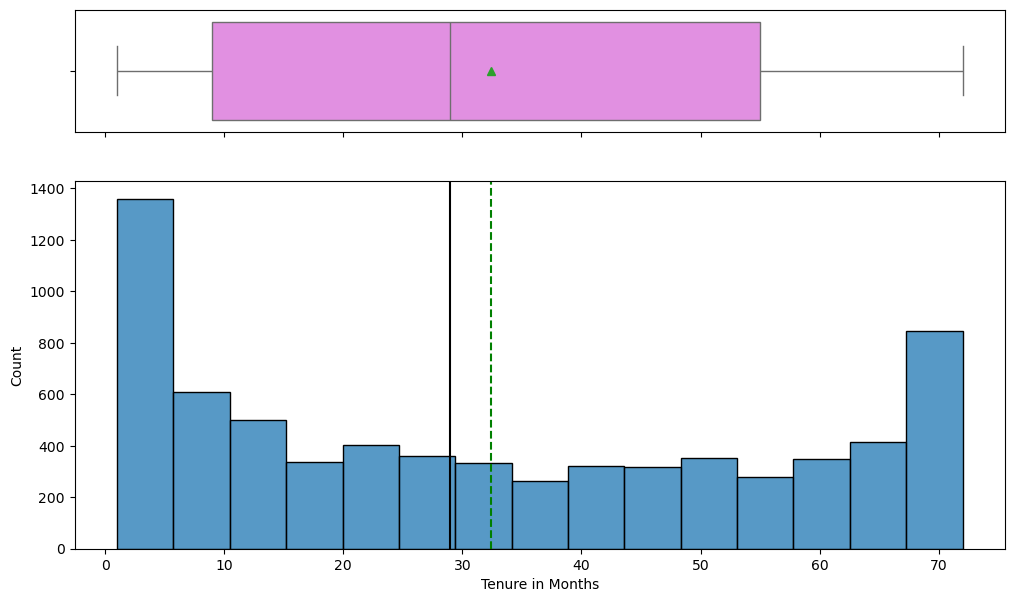

```python
# boxplot and histogram plots with repect to 'Tenure in Months' feature
histogram_boxplot(df_customer, "Tenure in Months")
```

#### **2. Monthly Charge**

- **Reason:** The cost of service impacts customer satisfaction and churn likelihood.
- **Visualization:** Histogram or box plot to explore the spread of monthly charges.
- **Insights:** Detect the pricing distribution and potential outliers.

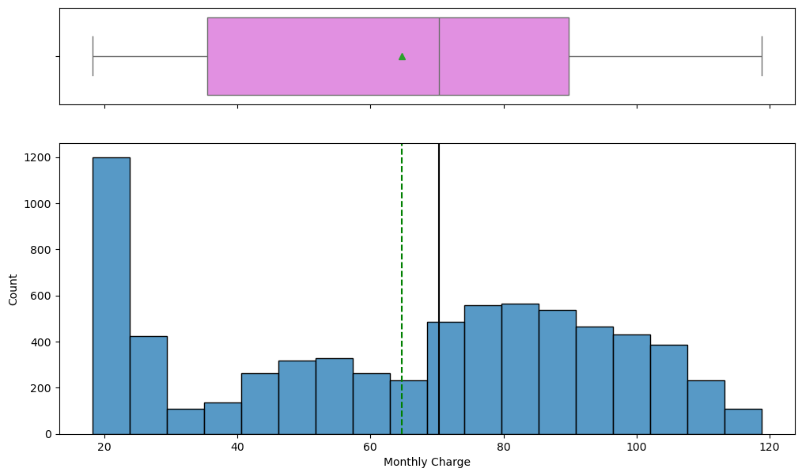

```python
# boxplot and histogram plots with repect to 'Monthly Charges' feature
histogram_boxplot(df_customer, "Monthly Charge")
```

#### **Interpretations:**

- **The interquartile range (IQR), i.e., the middle 50% of the data are located between 35 and 90.**
- **The median (50th percentile) of the monthly charge is 70 and the mean is about 65.**
- **There are no observed Outliers (customers with significantly low or high monthly charge compared to the majority).**
- **The highest bar indicating the most common monthy charge corresponds to ~20.**
- **A normal distribution (Bell-shaped) is observed between 40 and 120 with a mean of 80 (most customers have similar charges).**
- **The distribution of the "Monthly Charge" feature do not show a skewed plot.**

#### **3. Total Charges**

- **The cumulative charges incurred by a customer.**
- **Insights: Combines tenure and monthly charge information, relevant for long-term revenue impact.**

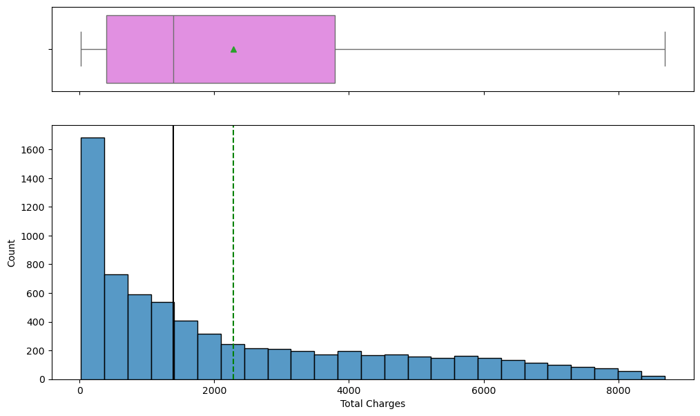

```python
# boxplot and histogram plots with repect to 'Total Charges' feature
histogram_boxplot(df_customer, "Total Charges")
```

#### **Interpretations:**

- **The interquartile range (IQR), i.e., the middle 50% of the data are located between 375 and 3750.**
- **The median (50th percentile) of the monthly charge is 1400 and the mean is about 2200.**
- **As the mean is greater than the median, the distribution is right-skewed.**
- **There are no observed Outliers (customers with significantly low or high monthly charge compared to the majority).**
- **The number of customers gradually decreases as the total charges increase.**

#### **4. Churn Score**

- **A pre-calculated score indicating how likely a customer is to churn.**
- **Insights: Analyzing the distribution can help visualize customer risk segments.**

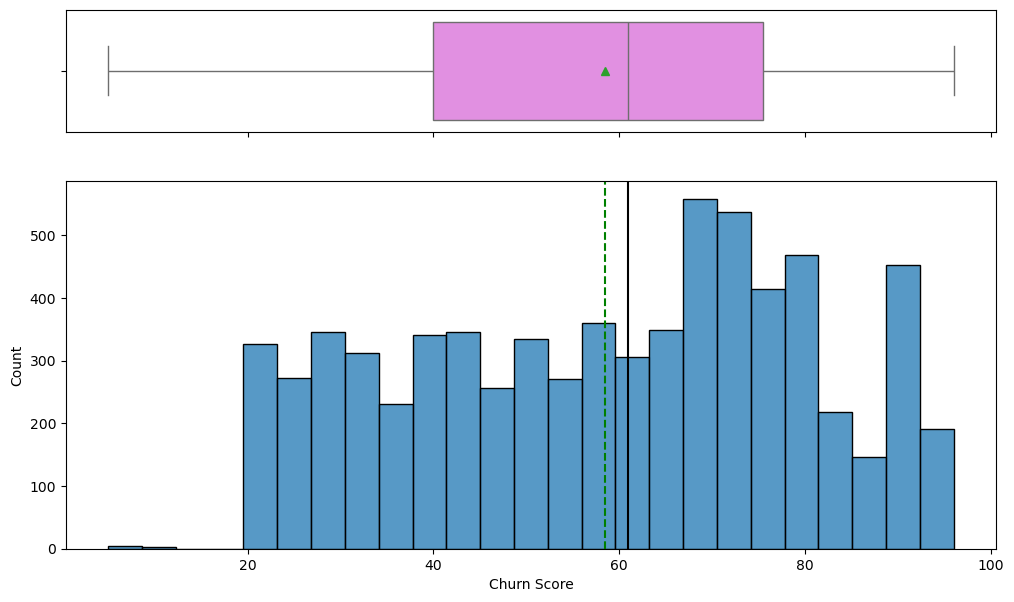

```python
# boxplot and histogram plots with repect to 'Churn Score' feature
histogram_boxplot(df_customer, "Churn Score")
```

#### **5. CLTV (Customer Lifetime Value)**

- **The predicted revenue a customer will generate over their lifetime.**
- **Insights: Higher CLTV might correlate with better retention or be inversely related if costs are prohibitive.**

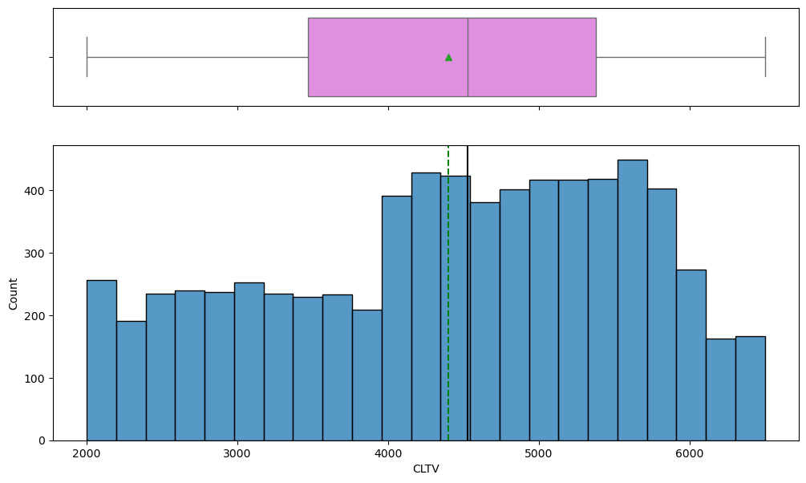

```python
# boxplot and histogram plots with repect to 'CLTV' feature
histogram_boxplot(df_customer, "CLTV")
```

#### **6. Total Long Distance Charges**

- **Represents charges for long-distance calls.**
- **Insights: Can help identify if this service contributes significantly to churn behavior.**

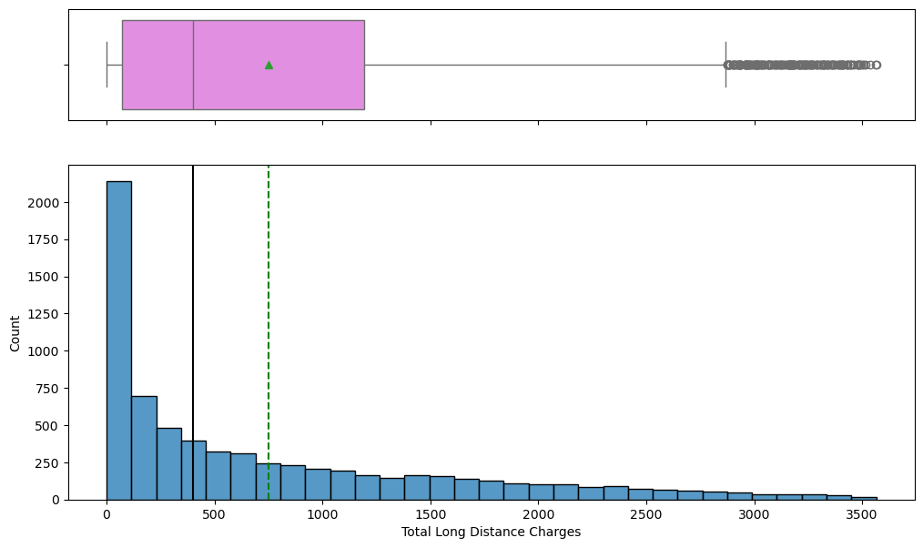

```python
# boxplot and histogram plots with repect to 'Total Long Distance Charges' feature
histogram_boxplot(df_customer, "Total Long Distance Charges")
```

## **Categorical Features**

```python
# Function to create labeled barplots
def labeled_barplot(data, feature, perc=False, n=None):
    """
    Barplot with percentage at the top

    data: dataframe
    feature: dataframe column
    perc: whether to display percentages instead of count (default is False)
    n: displays the top n category levels (default is None, i.e., display all levels)
    """

    total = len(data[feature])  # length of the column
    count = data[feature].nunique()
    if n is None:
        plt.figure(figsize=(count + 1, 5))
    else:
        plt.figure(figsize=(n + 1, 5))

    plt.xticks(rotation=90, fontsize=10)
    ax = sns.countplot(
        data=data,
        x=feature,
        palette="Paired",
        order=data[feature].value_counts().index[:n].sort_values(),
    )

    for p in ax.patches:
        if perc == True:
            label = "{:.1f}%".format(
                100 * p.get_height() / total
            )  # percentage of each class of the category
        else:
            label = p.get_height()  # count of each level of the category

        x = p.get_x() + p.get_width() / 2  # width of the plot
        y = p.get_height()  # height of the plot

        ax.annotate(
            label,
            (x, y),
            ha="center",
            va="center",
            size=9,
            xytext=(0, 5),
            textcoords="offset points",
        )  # annotate the percentage

    plt.show()  # show the plot
```

#### **1. Contract**

- **Represents the type of contract (Month-to-Month, One Year, Two Year).**
- **Insights: Helps visualize contract preferences and their relation to churn rates.**

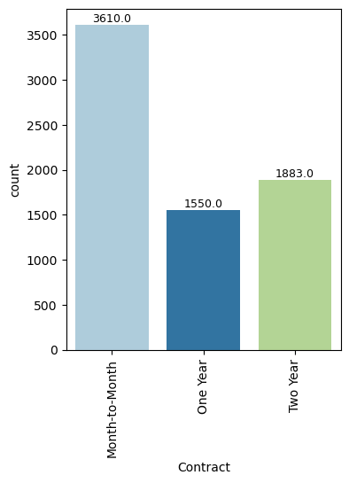

```python
labeled_barplot(df_customer, "Contract")
```

### **Interpretations**

The results from the univariate analysis for the Contract feature are as follows:

- **Month-to-Month:** 3610 customers (~51.3%).
- **One Year:** 1550 customers (~22.0%).
- **Two Year:** 1883 customers (~26.7%).

#### **Key Insights:**

**1. Dominance of Month-to-Month Contracts:**

- The majority of customers (51.3%) prefer month-to-month contracts.
- This suggests a preference for flexibility and the ability to cancel without long-term commitments.
- However, this group may have a higher churn risk, as customers on shorter contracts are less "locked in".

**2. Long-Term Contracts (One Year and Two Year):**

- Customers with one-year contracts make up ~22%, while two-year contracts account for ~26.7%.
- These customers are more likely to be retained, as they are committed to the service for a longer period.
- The higher percentage of two-year contracts compared to one-year contracts suggests that longer-term commitments might have been incentivized (e.g., discounts).

**3. Potential Correlation with Churn:**

- Month-to-month contracts are often associated with higher churn rates because of their flexibility.
- Longer-term contracts may correlate with lower churn due to exit barriers (e.g., penalties for early termination).

**4. Actionable Insights:**

- Retention Strategies for Month-to-Month Customers: Focus on loyalty programs or value-added services to retain these customers.
- Incentives for Long-Term Contracts: Increase adoption of one-year and two-year contracts by offering discounts, better bundles, or exclusive benefits.

#### **Next Steps for Analysis:**

- Perform a bivariate analysis to examine how the 'Contract' feature correlates with 'Churn'. For example:
  - What percentage of customers in each contract type churn?
  - Are long-term contracts significantly reducing churn?

#### **2. Internet Type**

- **Describes the type of internet service (Fiber Optic, DSL, Cable).**
- **Insights: Shows the popularity of different internet types and any correlation with churn.**

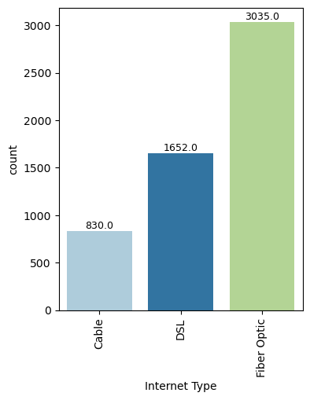

```python
labeled_barplot(df_customer, "Internet Type")
```

### **Interpretations**

The results from the univariate analysis for the Internet Type feature are as follows:

- **Fiber Optic: 3035 customers (~43.1%).**
- **DSL: 1652 customers (~23.5%).**
- **Cable: 830 customers (~11.8%).**

#### **Key Insights:**

**1. Fiber Optic Dominance:**

- Around 23.5% of customers use DSL (Digital Subscriber Line).
- DSL typically offers slower speeds compared to Fiber Optic but may still meet the needs of customers in areas where high-speed alternatives are unavailable or unnecessary.

**3. Lower Adoption of Cable:**

- Only 11.8% of customers are on Cable internet.
- This could reflect either limited availability of cable services or that customers are opting for newer technologies like Fiber Optic.
- Cable's shared bandwidth model may also deter customers due to slower speeds during peak usage times.

**4. Implications for Customer Retention:**

- Fiber Optic customers might have higher expectations for speed and reliability, so retaining them may require ensuring top-notch service quality.
- DSL and Cable customers could represent segments where there is potential to upsell faster services or migrate them to Fiber Optic plans.

**5. Potential Relationship with Churn:**

- Analyze churn rates across different internet types to identify any patterns. For example:
- Are DSL or Cable customers churning more frequently due to slower speeds or outdated technology?
- Are Fiber Optic customers more likely to remain loyal due to satisfaction with speed and performance?

#### **Next Steps for Analysis:**

- Perform a bivariate analysis between 'Internet Type' and 'Churn' to see if specific internet types are linked to higher churn.
- Investigate the geographic distribution of each internet type (e.g., urban vs. rural) to determine if location impacts customer preferences.
- Explore other features, such as Monthly Charge, to see how pricing varies by internet type. This may reveal insights about customer affordability and satisfaction.

#### **3. Payment Method**

- **Indicates the payment method used (Bank Withdrawal, Credit Card, Mailed Check).**
- **Insights: Can reveal preferences in payment options and their impact on customer retention.**

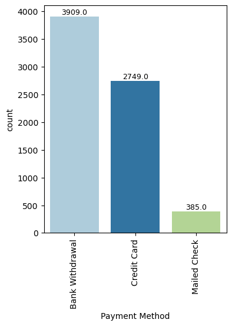

```python
labeled_barplot(df_customer, "Payment Method")
```

### **Interpretations**

The results from the univariate analysis for the Payment Method feature are as follows:

- **Bank Withdrawal: 3909 customers (~55.5%).**
- **Credit Card: 2749 customers (~39%).**
- **Mailed Check: 385 customers (~5.5%).**

#### **Key Insights:**

**1. Bank Withdrawal Dominates:**

- A majority of customers (~55.5%) use Bank Withdrawal as their payment method.
- This suggests a strong preference for automatic and recurring payment methods, which are generally more convenient and reduce the likelihood of missed payments.

**2. Credit Card Usage is Significant:**

- About 39% of customers prefer paying with a Credit Card.
- This could indicate a segment of customers who value flexibility or prefer credit card rewards and benefits.

**3. Low Use of Mailed Checks:**

- Only about 5.5% of customers use Mailed Checks for payment.
- This small group may represent customers who are more traditional or less comfortable with digital/automatic payment systems. These customers could also face barriers to adopting online payment methods, such as limited access to technology or online banking.

**4. Implications for Customer Retention:**

- Bank Withdrawal users are less likely to churn due to the ease of automatic payments, as manual payment effort is reduced.
- Credit Card users might churn if they perceive higher charges or lose the perceived benefits of paying via credit cards.
- Mailed Check users may be at higher risk of churn due to the inconvenience of this method, especially if competing service providers encourage more seamless payment options.

**5. Potential Relationship with Churn:**

Analyze churn rates across the three payment methods:

- Are Mailed Check users more likely to churn due to the inconvenience of manual payments?
- Do Credit Card users churn if they face unexpected fees or limitations?
- Are Bank Withdrawal users the most stable due to automatic payment setup?

**6. Customer Segmentation Opportunity:**

- Consider encouraging Mailed Check users to switch to digital methods by offering discounts or benefits.
- Analyze whether Bank Withdrawal customers are more satisfied or have longer tenure compared to the other groups.

#### **Next Steps for Analysis:**

**1. Bivariate Analysis with Churn:** Examine how churn rates vary across different payment methods to identify high-risk groups.

**2. Demographic Segmentation:** Explore demographic features (e.g., age, senior citizen status) to understand the profiles of customers using each payment method.

**3. Monthly Charge Comparison:** Investigate whether customers on specific payment methods have higher/lower average monthly charges, as this could influence their payment preferences.

**4. Adoption of Digital Payments:** For Mailed Check users, analyze barriers to adopting digital payments and assess whether incentivizing a shift could improve retention.

#### **4. Offer**

- **Represents promotional offers (Offer A, Offer B, etc.).**
- **Insights: Helps identify the effectiveness of offers and their influence on customer behavior.**

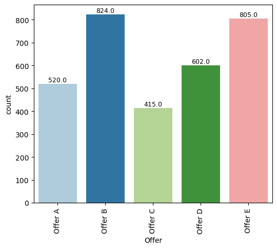

```python
labeled_barplot(df_customer, "Offer")
```

### **Key Insights:**

**4. Implications for Customer Retention:**

- Popular offers like Offer B and Offer E could be designed to target a broader customer base and might contribute to lower churn rates.
- Offer C's low adoption might correlate with higher churn or dissatisfaction, as it may not meet customer expectations effectively.

**5. Opportunities for Marketing Optimization:**

- Investigate why Offer B and Offer E are performing well. Are they providing better discounts, benefits, or services? Understanding their success can help refine future offers.
- Analyze the shortcomings of Offer C to understand why it is less attractive. Revamping this offer or replacing it with a new one might improve customer engagement.

**6. Possible Offer Segmentation:**

- Each offer may appeal to different customer demographics or usage patterns. For example:
  - Offer B and Offer E could target high-usage customers or those with higher churn risk.
  - Offer A and Offer D may cater to customers with moderate needs or specific service preferences.
  - Offer C might need more incentives or improvements to attract a larger share of customers.

**7. Connection to Churn:**

- Analyze how each offer correlates with churn rates:
  - Are customers on Offer B or Offer E less likely to churn due to better benefits?
  - Are customers on Offer C more likely to churn, indicating dissatisfaction or unmet needs?

#### **Next Steps for Analysis:**

**1. Bivariate Analysis with Churn:**

- Examine churn rates for each offer to identify which offers are most effective at retaining customers.

**2. Demographic Analysis:**

- Explore which customer segments (age, gender, income, etc.) prefer each offer to optimize marketing and service strategies.

**3. Usage Patterns:**

- Investigate whether customers on certain offers have higher average monthly charges or different service preferences.

**4. Feedback Collection:**

- Use customer surveys or feedback to gather insights into the strengths and weaknesses of each offer.

By focusing on improving underperforming offers and leveraging successful ones, the company can enhance customer satisfaction and retention.

#### **5. Customer Status**

- **Indicates whether the customer is active, joined, or churned.**
- **Insights: Can be analyzed to find relationships with churn status and longevity.**

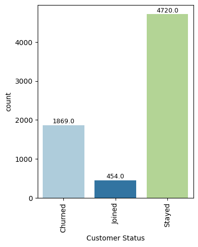

```python
labeled_barplot(df_customer, "Customer Status")
```

### **Interpretations**

The results for the Customer Status feature using labeled_barplot() are as follows:

- **Stayed: 4720 customers (~67.0%).**
- **Churned: 1869 customers (~26.5%).**
- **Joined: 454 customers (~6.5%).**

#### **Key Insights:**

**1. Majority of Customers Stayed:**

- The majority of customers (4720, ~67.0%) have stayed with the company, indicating a relatively stable customer base.
- This suggests that the company is successful at retaining a significant portion of its customers.

**2. Churn Rate is Significant:**

- A substantial portion of the customer base (1869, ~26.5%) has churned. While the majority of customers remain loyal, the churn rate is notable and represents an area for improvement.
- Addressing churn could lead to significant revenue retention and growth opportunities.

**3. Small Number of New Customers:**

- Only 454 customers (~6.5%) are classified as having recently joined.
- This indicates a lower acquisition rate compared to the existing customer base, which could suggest limited growth or challenges in attracting new customers.

**4. Implications for Business Strategy:**

- Retention Focus: Retaining the "Stayed" customers is crucial for maintaining revenue stability. The company should focus on improving satisfaction and loyalty among this group.
- Reducing Churn: The "Churned" segment is a key concern. Analyzing churn drivers (e.g., dissatisfaction, competition, or price sensitivity) is critical to identifying strategies to minimize churn.
- Boosting Acquisitions: The low proportion of "Joined" customers suggests a need for better marketing strategies, competitive pricing, or promotional campaigns to attract new customers.

#### **Business Implications:**

**1. Churn Analysis:**

- Perform detailed bivariate and multivariate analyses to understand which features (e.g., contract type, offers, customer demographics) are most strongly correlated with churn.
- Develop targeted retention strategies for high-risk segments, such as customers with month-to-month contracts or those dissatisfied with service quality.

**2. Customer Retention:**

- Focus on rewarding loyal customers in the "Stayed" group to prevent them from moving to the churned segment. For example:
  - Loyalty discounts.
  - Enhanced service offerings.
  - Personalized customer support.

**3. New Customer Acquisition:**

- Investigate why the "Joined" segment is small. Consider improving:
  - Marketing and advertising campaigns
  - Competitive offers to attract new customers
  - Partnerships and referrals to reach a broader audience

**4. Churn vs. Customer Status Trends:**

- Analyze the historical trend of the "Churned" vs. "Stayed" proportions to determine whether the churn rate is increasing, decreasing, or stable over time.
- Explore whether the "Joined" proportion has been stagnant and whether external factors (e.g., competition or market saturation) are influencing this.

#### **Next Steps:**

**1. Churn Driver Analysis:**

- Use features like "Churn Category" and "Churn Reason" to explore what is driving churn behavior in detail.

**2. Retention Strategy Design:**

- Create retention campaigns targeting high-risk customers, especially those on short-term contracts or those with low satisfaction scores.

**3. Growth Strategy for New Customers:**

- Develop innovative offers or pricing strategies to encourage more customer acquisition.

**4. Segmentation Analysis:**

- Segment customers based on demographics, payment methods, and tenure to understand which groups are more likely to churn, stay, or join.

By focusing on reducing churn and increasing new customer acquisitions, the company can improve its overall customer base and revenue.

#### **6. Churn Category**

- **Indicates whether the Churn Category is Attitude, Competitor, Dissatisfaction, Price or Other.**
- **Insights: Can be analyzed to find relationships with churn status and longevity.**

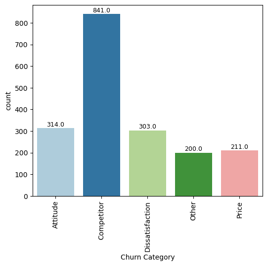

```python
labeled_barplot(df_customer, "Churn Category")
```

### **Interpretations**

The results for the Churn Category feature using labeled_barplot() are as follows:

#### **Key Insights:**

**1. Competitor as the Leading Churn Driver:**

- The majority of churned customers (841, ~45.0%) left due to competition. This suggests that other service providers are offering better deals, services, or benefits that are attractive to customers.
- The company is losing a significant share of its customers to competitors, highlighting a need for competitive analysis and improved offerings.

**2. Customer Dissatisfaction is a Significant Concern:**

- Dissatisfaction accounts for 303 churn cases (~16.2%), which indicates that many customers are unhappy with some aspect of the company's service or products.
- This could be linked to factors such as service quality, product performance, or unfulfilled expectations.

**3. Attitude of Service or Support:**

**4. Price Sensitivity:**

- 211 customers (~11.3%) cited price as their reason for churn. This indicates that some customers perceive the company's pricing as too high or not providing adequate value for money.
- Offering competitive pricing plans or discounts might help retain this segment of customers.

**5. Other Reasons:**

- The remaining 200 churn cases (~10.7%) fall into the "Other" category, which could include various reasons not captured by the predefined categories (e.g., personal circumstances, changes in preferences, etc.).

#### **Business Implications:**

**1. Addressing Competitive Pressure:**

- **Competitive Analysis:** Study competitors' offerings, including pricing, service quality, and added benefits, to identify gaps in the company’s offerings.
- **Value Proposition:** Highlight and market unique features of the company’s products/services that competitors lack.
- **Promotional Campaigns:** Offer targeted promotions to win back customers who left for competitors.

**2. Improving Customer Satisfaction:**

- **Root Cause Analysis:** Investigate areas of dissatisfaction through customer feedback or surveys.
- **Service Improvements:** Enhance product quality, reliability, and overall service delivery to meet or exceed customer expectations.

**3. Enhancing Customer Service Quality:**

- **Employee Training:** Train customer-facing employees on communication, problem resolution, and maintaining a positive attitude.
- **Support Tools:** Invest in advanced customer support tools and self-service options to enhance the customer experience.

**4. Price Competitiveness:**

- **Tiered Pricing:** Offer a range of pricing plans to cater to customers with varying budgets.
- **Discounts and Loyalty Rewards:** Provide discounts or loyalty rewards to long-term customers or those on the verge of churning due to price concerns.

**5. Exploring "Other" Reasons:**

- **Further Classification:** Analyze the "Other" category to identify hidden trends or new churn drivers.
- **Personalized Retention Strategies:** Use customer segmentation and personalized offers to address unique customer needs.

#### **Next Steps:**

**1. Competitor-Focused Retention Campaigns:** Use personalized win-back offers for customers who churned due to competition.

**2. Customer Feedback Analysis:** Gather insights on dissatisfaction and attitude-related churn to address specific pain points.

**3. Price Sensitivity Testing:** Conduct A/B testing of pricing models to find the sweet spot that balances customer satisfaction and profitability.

**4. Retention Tracking:** Monitor churn patterns over time to assess the impact of implemented strategies.

By addressing the major churn drivers like competition, dissatisfaction, and pricing, the company can improve retention and customer loyalty.

### **Target Variable**

```
Churn
0    5174
1    1869
Name: count, dtype: int64
```

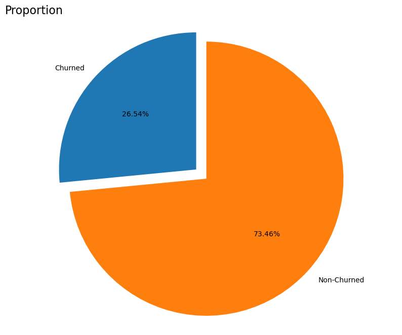

```python
print(df_customer.Churn.value_counts())
labels = 'Churned', 'Non-Churned'
#sizes = [ds.is_promoted[ds['is_promoted']==1].count(), ds.is_promoted[ds['is_promoted']==0].count()]
sizes = [df_customer.Churn[df_customer['Churn']==1].count(), df_customer.Churn[df_customer['Churn']==0].count()]
explode = (0, 0.1)
fig1, ax1 = plt.subplots(figsize=(10, 8))
ax1.pie(sizes, explode=explode, labels=labels, autopct='%1.2f%%',
        shadow=False, startangle=90)
ax1.axis('equal')
plt.title("Proportion", size = 16, loc="left")
plt.show()
```

### **Interpretations**

The target variable, Churn, represents whether customers have churned or not, and the pie chart distribution is as follows:

- **Non-Churned (0):** 5,174 customers (~73.5%).
- **Churned (1):** 1,869 customers (~26.5%).

#### **Key Insights:**

**1. Majority of Customers Stay:**

- The majority of customers (73.5%) have not churned, indicating that most customers are retained successfully.

**2. Significant Churn Rate:**

- Around 26.5% of customers have churned, which represents a notable proportion of the customer base.
- This suggests there is a need to focus on retention strategies and address key churn drivers.

**3. Business Implications:**

- While the retention rate is relatively high, a churn rate of 26.5% could have significant revenue implications.
- It is crucial to identify and address factors contributing to customer churn (e.g., competition, dissatisfaction, pricing).

#### **Next Steps:**

- Perform bivariate and multivariate analysis to identify relationships between churn and other features.
- Focus on creating predictive models to target at-risk customers for churn reduction strategies.

## **Bivariate analysis**

### **Numerical Features**

```python
### Function to plot distributions
def distribution_plot_wrt_target(data, predictor, target):

    fig, axs = plt.subplots(2, 2, figsize=(12, 10))

    target_uniq = data[target].unique()

    axs[0, 0].set_title("Distribution of Churn for Churn=" + str(target_uniq[0]))
    sns.histplot(
        data=data[data[target] == target_uniq[0]],
        x=predictor,
        kde=True,
        ax=axs[0, 0],
        color="teal",
    )

    axs[0, 1].set_title("Distribution of Churn for Churn=" + str(target_uniq[1]))
    sns.histplot(
        data=data[data[target] == target_uniq[1]],
        x=predictor,
        kde=True,
        ax=axs[0, 1],
        color="orange",
    )

    axs[1, 0].set_title("Boxplot w.r.t Churn")
    sns.boxplot(data=data, x=target, y=predictor, ax=axs[1, 0], palette="gist_rainbow")

    axs[1, 1].set_title("Boxplot (without outliers) w.r.t Churn")
    sns.boxplot(
        data=data,
        x=target,
        y=predictor,
        ax=axs[1, 1],
        showfliers=False,
        palette="gist_rainbow",
    )

    plt.tight_layout()
    plt.show()
```

### **1. Churn vs. Tenure in Months**

- **Purpose:** Investigate how the duration of customer tenure influences churn.
- **Insights:**
  - Shorter-tenure customers might exhibit higher churn due to a lack of satisfaction or loyalty.
  - Longer-tenure customers are more likely to stay unless they experience dissatisfaction or receive competitor offers.

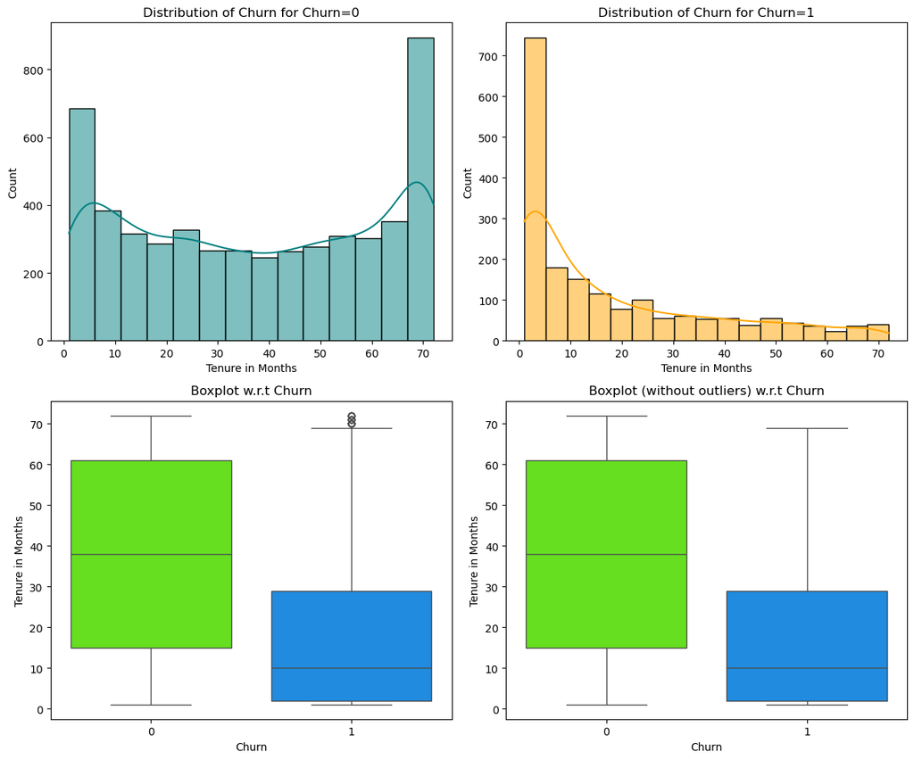

```python
distribution_plot_wrt_target(df_customer, "Tenure in Months", "Churn")
```

### **Interpretations**

#### **1. Insights from sns.histplot:**

**Churn = 0 (Customers who did not churn):**

**Churn = 1 (Customers who churned):**

- **Observations:**
  - The distribution is right-skewed, with a very high count of churn for customers with tenure between 1-5 months.
  - The number of churned customers declines significantly as tenure increases.
- **Interpretation:**
  - Customers with short tenures (1-5 months) are much more likely to churn, possibly due to dissatisfaction, unmet expectations, or a better offer from competitors early in their subscription period.
  - The decline in churn with increasing tenure suggests that customers who stay longer become more loyal or are less likely to churn.

#### **2. Insights from sns.boxplot:**

**Churn = 0 (Customers who did not churn):**

- **Observations:**
  - The mean tenure for customers who did not churn is 38 months.
  - The interquartile range (IQR) suggests that most customers who stay have moderate to long tenures.
- **Interpretation:**
  - Customers who stay tend to have medium to long tenures, reflecting satisfaction with the service or reluctance to change.

**Churn = 1 (Customers who churned):**

- **Observations:**
  - The mean tenure for churned customers is approximately 10 months, which is significantly lower than for those who stayed.
  - There are some outliers where churn occurs at longer tenures.
- **Interpretation:**
  - The low mean tenure indicates that churn is most prevalent among customers who have not developed loyalty or satisfaction with the service.
  - The presence of outliers suggests that even long-tenured customers occasionally churn, likely due to dissatisfaction, service changes, or external factors.

#### **Overall Implications:**

- **1. Short-tenure customers** are the most at risk for churn:
  - These customers need targeted onboarding strategies and early engagement programs to ensure they don’t leave early.
- **2. Long-tenure customers** show a strong tendency to stay but shouldn’t be ignored:
  - Companies should focus on maintaining satisfaction and loyalty through rewards, discounts, or enhanced services.
- **3. Outliers for churned long-tenure customers** require further analysis:
  - Investigating why loyal customers churn after long relationships could highlight service issues or unmet needs.

#### **Actions for Business:**

- Implement a retention strategy specifically for new customers in their first year to reduce churn.
- Provide incentives (e.g., loyalty programs or tailored offers) to maintain long-tenure customers.
- Conduct surveys for long-tenure customers who churn to understand the root causes and address service gaps.

### **2. Churn vs. Monthly Charges**

- **Purpose:** Examine how monthly charges affect churn likelihood.
- **Insights:**
  - High monthly charges might correlate with higher churn rates if customers feel the cost is unjustified.
  - Conversely, very low charges might indicate basic services that fail to meet expectations, leading to churn.

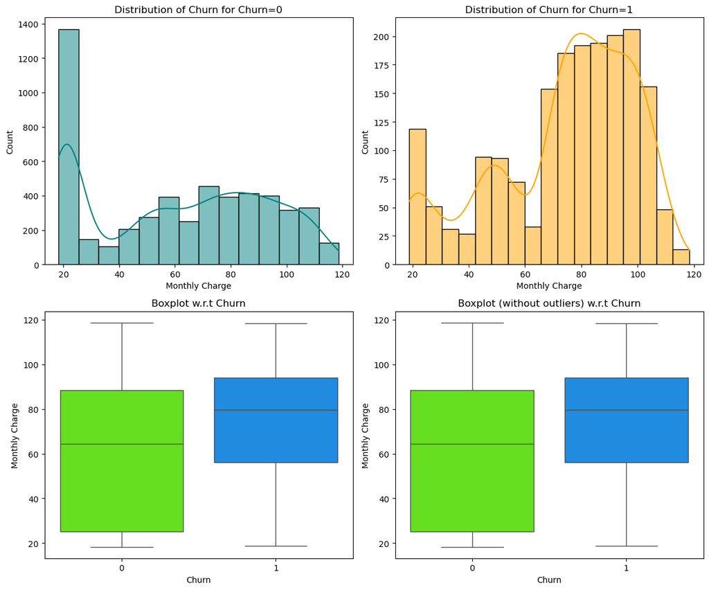

```python
distribution_plot_wrt_target(df_customer, "Monthly Charge", "Churn")
```

### **Interpretations**

**2. Observations from the sns.boxplot:**

- **1. For Churn = 0:**
  - **Mean Monthly Charges:** ~65.
  - **Distribution:** Customers who stay have a slightly lower mean monthly charge compared to churned customers, suggesting that moderate pricing may contribute to retention.
  - **No Outliers:** Indicates that the range of monthly charges for non-churned customers is relatively consistent.
- **For Churn = 1:**
  - **Mean Monthly Charges:** ~80.
  - **Distribution:** Customers who churn tend to have higher monthly charges on average, suggesting that cost could be a factor driving churn.
  - **No Outliers:** The data distribution is also consistent for churned customers, indicating no extreme cases of exceptionally high charges influencing the analysis.

**3. Insights and Key Takeaways:**

- **1. Higher Monthly Charges are Associated with Churn:**
  - The average monthly charge for churned customers (~80) is higher than for non-churned customers (~65). This suggests that cost sensitivity could be a factor for higher-tier customers.
- **2. Retention Across Low Monthly Charges:**
  - For both churned and non-churned customers, there is a noticeable group with low monthly charges (~20-40). This suggests that retaining low-paying customers may require ensuring basic plans meet expectations and offer sufficient value.
- **3. Churn Peaks in the Mid-Tier and High-Tier Groups:**
  - Churned customers are concentrated around monthly charges of ~50 and ~90. This could indicate dissatisfaction with the perceived value of mid-tier or premium services or affordability concerns for these customer segments.
- **4. Cost vs. Value Analysis:**
  - The analysis highlights the importance of ensuring that customers in the mid- to high-tier pricing groups perceive value for the services they receive. This could involve improved service quality, additional benefits, or loyalty rewards to mitigate churn.

**4. Business Recommendations:**

- **1. Focus on High-Tier Customers:**
  - For customers paying high monthly charges (~70-120), ensure premium services deliver exceptional value and meet expectations. Conduct surveys or feedback sessions to identify areas for improvement.
- **2. Target Mid-Tier Customers:**
  - Customers with monthly charges of ~50 show significant churn. Offering tailored promotions, discounts, or value-added services could improve retention.
- **3. Retention Strategies for Low-Tier Customers:**
  - For customers with low monthly charges (~20-40), provide consistent service quality and clear communication about the benefits of upgrading to higher-tier plans.
- **4. Pricing Optimization:**
  - Consider revisiting pricing structures to align with customer expectations and perceived value, especially in the mid-tier segment where churn is prominent.
- **5. Proactive Churn Prevention:**
  - Use predictive analytics to identify at-risk customers in the high- and mid-tier pricing ranges and offer targeted retention strategies, such as discounts, enhanced services, or loyalty incentives.

### **3. Churn vs. Total Charges**

- **Purpose:** Analyze the relationship between total charges (cumulative spending) and churn behavior.
- **Insights:**
  - Higher total charges might indicate long-term customers with a lower churn rate.
  - Sudden churn in high-total-charge customers could point to dissatisfaction or unexpected service issues.

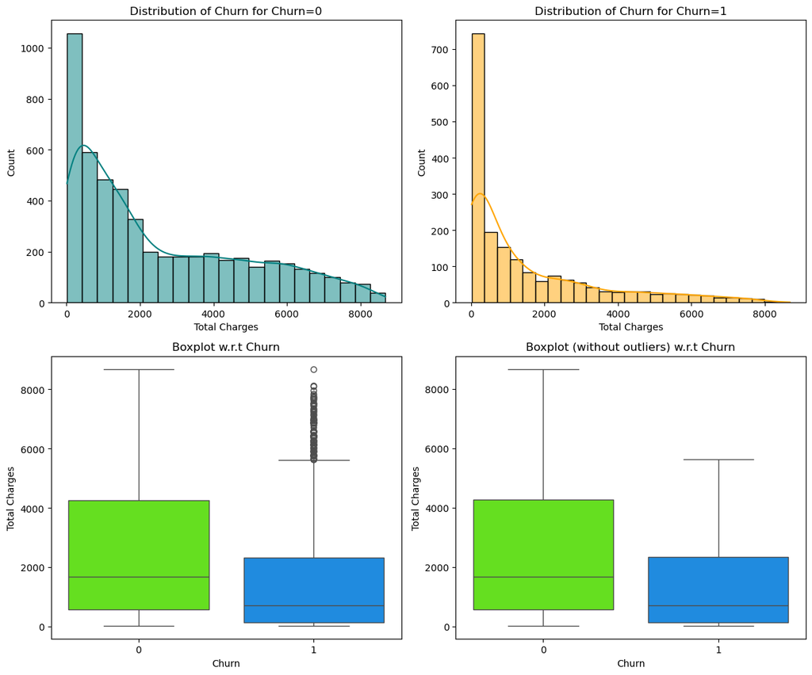

```python
distribution_plot_wrt_target(df_customer, "Total Charges", "Churn")
```

### **Interpretations**

**1. Observations from histplot:**

**2. Observations from boxplot:**

**For Churn = 0 (Non-Churned Customers):**

- **Mean Total Charges:** ~1600.
- The absence of outliers indicates that the spending pattern for non-churned customers is relatively consistent.
- Higher average Total Charges for non-churned customers reflect longer tenures or higher-tier service subscriptions.

**For Churn = 1 (Churned Customers):**

- **Mean Total Charges:** ~800.
- The lower mean Total Charges for churned customers suggest that low-paying customers are more likely to churn.
- The presence of outliers above 6000 Total Charges indicates that while most churned customers are low-paying, a small subset of high-value customers also churned. These high-value churns may indicate dissatisfaction despite high spending.

**4. Business Recommendations:**

- **1. Focus Retention Efforts on Low-Paying Customers:**
  - Since most churned customers have low Total Charges, targeted retention strategies such as discounts, additional features, or tailored engagement programs can help reduce churn in this segment.
- **2. Investigate High-Value Churns:**
  - Analyze the reasons behind the outliers with high Total Charges (>6000) who churned. These customers represent significant revenue and may highlight service or satisfaction issues.
- **3. Strengthen Engagement for New Customers:**
  - Low Total Charges often correspond to short-tenure customers. Develop onboarding and engagement strategies to build loyalty early and reduce churn in this group.
- **4. Encourage Long-Term Plans or Upselling:**
  - Higher Total Charges correlate with lower churn rates. Incentivize customers to upgrade their plans or commit to longer contracts to increase Total Charges and reduce churn likelihood.
- **5. Monitor Spending Trends:**
  - Regularly analyze spending patterns to identify at-risk customers (e.g., those with decreasing Total Charges) and proactively address potential churn triggers.

**By addressing the factors behind low- and high-value customer churn, businesses can implement tailored strategies to improve retention and maximize revenue.**

### **4. Churn vs. CLTV (Customer Lifetime Value)**

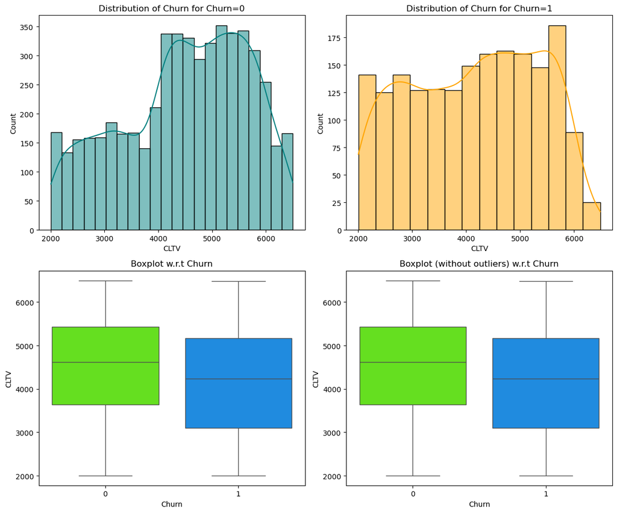

```python
distribution_plot_wrt_target(df_customer, "CLTV", "Churn")
```

### **Interpretations**

**1. Observations from histplot:**

**For Churn = 0 (Customers who did not churn):**

- **1. Distribution in the Interval 2000–4000:**
  - The distribution is relatively uniform, with an average count of approximately 160.
  - This suggests that non-churned customers are consistently distributed across this range of lower CLTV values.
  - Customers in this range might be paying for basic or mid-level services, contributing moderate revenue over their lifetime.
- **2. Distribution in the Interval 3500–6500:**
  - A normal distribution is observed in this range, peaking at a mean CLTV of ~5000, with the maximum count of 350.
  - This range represents customers with higher revenue contributions, likely due to longer tenures, premium services, or add-ons.
  - This peak highlights a strong retention of customers in this range, showing that high-value customers tend to stay.

**For Churn = 1 (Customers who churned):**

- **1. Uniform Distribution:**
  - The distribution is approximately uniform across most of the range, with a mean count of ~140.
  - This indicates churn across various CLTV levels, though the counts are slightly lower than those for non-churned customers.
- **2. Drop in Churn for CLTV Above 6000:**
  - There are few churned customers with CLTV values above 6000, indicating that very high-value customers tend to stay.
  - This suggests that high CLTV is a protective factor against churn, as these customers likely perceive sufficient value in the services they receive.

**2. Observations from boxplot:**

- **1. For Churn = 0 (Non-Churned Customers):**
  - **Mean CLTV:** ~4600.
  - Non-churned customers have a slightly higher mean CLTV compared to churned customers, indicating that higher CLTV is associated with customer retention.
  - The absence of outliers suggests a consistent pattern of CLTV for non-churned customers, with no extreme variations.
- **2. For Churn = 1 (Churned Customers):**
  - Mean CLTV: ~4300.
  - Churned customers have a slightly lower mean CLTV compared to non-churned customers, which aligns with the idea that lower-value customers are more likely to churn.
  - No outliers are observed, indicating a consistent distribution of CLTV for churned customers.

**3. Insights and Key Takeaways:**

- **1. High CLTV is Linked to Retention:**
  - Non-churned customers generally have higher CLTV values (~4600 on average) compared to churned customers (~4300). This suggests that increasing CLTV is a key strategy for reducing churn.
- **2. Uniform Churn Across Lower CLTV Ranges:**
  - The uniform distribution of churned customers across the lower CLTV range (2000–4000) highlights that low-value customers are at higher risk of churn, potentially due to dissatisfaction with basic services or limited perceived value.
- **3. Retention of Very High CLTV Customers:**
  - Few customers with CLTV above 6000 churn, demonstrating that high-value customers are more loyal, likely due to satisfaction with premium services or longer tenures.
- **4. Normal Distribution for Retained High-Value Customers:**
  - The normal distribution observed in the range 3500–6500 for non-churned customers suggests a strong concentration of medium- to high-value customers who are retained. These customers may benefit from targeted loyalty programs or incentives to maintain their satisfaction.

**4. Business Recommendations:**

- **1. Focus on Increasing CLTV:**
  - To reduce churn, focus on strategies that increase CLTV for at-risk customers. This could include cross-selling, upselling, or offering incentives to encourage longer-term contracts.
- **2. Retention Strategies for Low CLTV Customers:**
  - Customers in the lower CLTV range (2000–4000) are at higher risk of churn. Offering value-added services, personalized engagement, or targeted discounts could improve retention.
- **3. Prioritize High-CLTV Customers:**
  - High-CLTV customers (above 6000) have a low likelihood of churn, but ensuring their continued satisfaction is critical. Offer exclusive benefits, premium support, or loyalty rewards to maintain their loyalty.
- **4. Target the Mid-CLTV Range for Growth:**
  - The normal distribution in the mid-CLTV range (3500–6500) for retained customers indicates an opportunity to nurture and grow this segment. Offering tailored promotions or tiered services can increase CLTV and reduce churn further.
- **5. Monitor CLTV Trends Over Time:**
  - Regularly analyze CLTV trends across customer segments to identify patterns in churn risk and develop proactive retention strategies.

**By leveraging CLTV insights, businesses can identify key segments to target for retention and growth, ultimately improving customer satisfaction and reducing churn.**

### **5. Churn vs. Average Monthly Long Distance Charges**

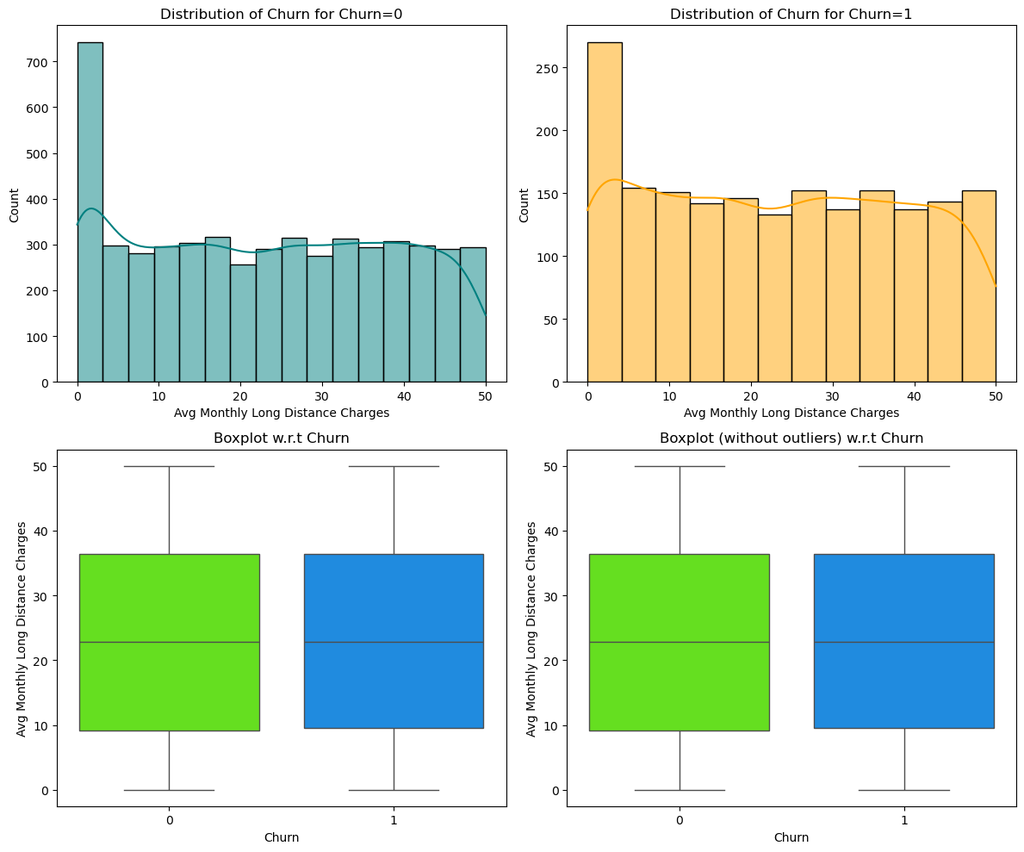

```python
distribution_plot_wrt_target(df_customer, "Avg Monthly Long Distance Charges", "Churn")
```

### **Interpretations**

**1. Observations from sns.histplot:**

**For Churn = 0 (Customers who did not churn):**

- **1. High Count for Low Long Distance Charges (0–3):**
  - A **high count (~750)** is observed for Average Monthly Long Distance Charges between 0 and 3, indicating that many non-churned customers have minimal long-distance charges.
  - This could correspond to customers with limited usage of long-distance calling features or lower-tier plans.
- **2. Uniform Distribution for 3–50:**
  - The distribution is roughly uniform with a mean count of about 300 for charges between 3 and 50.
  - This indicates that long-distance usage beyond the initial range is evenly distributed among non-churned customers, with no significant peaks or declines.

**For Churn = 1 (Customers who churned):**

**2. Observations from sns.boxplot:**

**For Both Churn = 0 and Churn = 1:**

- **Mean Long Distance Charges:** ~23 for both groups, indicating similar spending habits on long-distance services regardless of churn status.
- **No Outliers:** The absence of outliers suggests consistent usage patterns for long-distance charges among all customers.

**3. Insights and Key Takeaways:**

**4. Business Recommendations:**

**By analyzing long-distance usage in conjunction with other features, businesses can better understand customer behavior and design tailored strategies to improve retention.**

### **Categorical Features**

```python
# function to plot stacked bar chart
def stacked_barplot(data, predictor, target):
    """
    Print the category counts and plot a stacked bar chart

    data: dataframe
    predictor: independent variable
    target: target variable
    """
    count = data[predictor].nunique()
    sorter = data[target].value_counts().index[-1]
    tab1 = pd.crosstab(data[predictor], data[target], margins=True).sort_values(
        by=sorter, ascending=False
    )
    print(tab1)
    print("-" * 120)
    tab = pd.crosstab(data[predictor], data[target], normalize="index").sort_values(
        by=sorter, ascending=False
    )
    tab.plot(kind="bar", stacked=True, figsize=(count + 1, 5))
    plt.legend(
        loc="lower left",
        frameon=False,
    )
    plt.legend(loc="upper left", bbox_to_anchor=(1, 1))
    plt.show()
```

### **1. Churn vs. Contract**

```
Churn              0     1   All
Contract
All             5174  1869  7043
Month-to-Month  1955  1655  3610
One Year        1384   166  1550
Two Year        1835    48  1883
------------------------------------------------------------------------------------------------------------------------
```

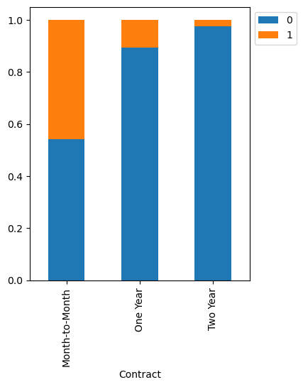

```python
stacked_barplot(df_customer, "Contract", "Churn")
```

### **Interpretations:**

**1. Overview of the Contract Distribution**

- **Total Customers:** 7043
  - **Month-to-Month Contracts:** 3610 (51.3%)
  - **One-Year Contracts:** 1550 (22.0%)
  - **Two-Year Contracts:** 1883 (26.7%)
- **Observation:**
  - Month-to-month contracts are the most common, followed by two-year contracts and then one-year contracts.

**2. Churn Distribution by Contract Type**

- **Overall Churn Rate:** ≈26.5%.
- **Churn Rates by Contract:**
  - **Month-to-Month:** ≈45.8% Almost half of the customers with month-to-month contracts churn. This indicates a lack of long-term commitment, making these customers more likely to leave.
  - **One-Year:** 10.7% Significantly lower churn compared to month-to-month contracts, suggesting a more stable customer base due to the longer commitment.
  - **Two-Year:** 2.5% The lowest churn rate is observed in two-year contracts, highlighting that customers with longer-term contracts are highly loyal.

**3. Churn Contribution by Contract**

- **Churn from Month-to-Month:** ≈88.5% A majority of churned customers are on month-to-month contracts.
- **Churn from One-Year:** ≈8.9% A small percentage of churn comes from one-year contracts.
- **Churn from Two-Year:** ≈2.6% The smallest proportion of churned customers are from two-year contracts.

**4. Insights and Business Implications**

- **a. Month-to-Month Contracts:**
  - Customers with **month-to-month contracts** are highly prone to churn, likely due to flexibility and lack of commitment.
  - **Recommendation:**
    - Introduce incentives (e.g., discounts or loyalty rewards) for month-to-month customers to switch to longer-term contracts.
    - Focus on addressing churn reasons (e.g., dissatisfaction, pricing concerns) for this group.
- **b. One-Year Contracts:**
  - Moderate churn rates indicate a relatively stable customer base compared to month-to-month contracts.
  - **Recommendation:**
    - Highlight the value of one-year contracts to month-to-month customers.
    - Consider offering renewal incentives to retain these customers.
- **c. Two-Year Contracts:**
  - Extremely low churn rates indicate that long-term contracts are effective at retaining customers.
  - **Recommendation:**
    - Continue promoting two-year contracts as a premium option.
    - Ensure that customers on two-year contracts remain satisfied by providing excellent service and targeted retention efforts.

**This analysis highlights the strong correlation between contract type and churn, offering actionable insights to reduce churn and improve retention strategies.**

### **2. Churn vs. Payment Method**

```
Churn               0     1   All
Payment Method
All              5174  1869  7043
Bank Withdrawal  2580  1329  3909
Credit Card      2351   398  2749
Mailed Check      243   142   385
------------------------------------------------------------------------------------------------------------------------
```

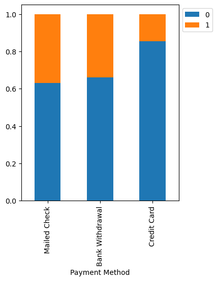

```python
stacked_barplot(df_customer, "Payment Method", "Churn")
```

### **Interpretations**

**1. Overview of the Payment Method Distribution**

- **Total Customers:** 7043
  - **Bank Withdrawal:** 3909 (55.5%)
  - **Credit Card:** 2749 (39.0%)
  - **Mailed Check:** 385 (5.5%)
- **Observation:**
  - Most customers use Bank Withdrawal or Credit Card for payment, while a small fraction relies on Mailed Checks.

**2. Churn Distribution by Payment Method**

- **Churn from Bank Withdrawal:** 71.1% A majority of churned customers are from the bank withdrawal payment method.
- **Churn from Credit Card:** 21.3% A significant portion of churned customers is from the credit card group, but the churn rate for this payment method is lower.
- **Churn from Mailed Check:** 7.6% A small fraction of churned customers use mailed checks, but the churn rate is high.

**4. Insights and Business Implications**

- **a. Bank Withdrawal:**
  - Customers using bank withdrawal are the largest group and contribute significantly to churn.
  - **Recommendation:**
    - Investigate potential pain points for customers using this payment method (e.g., technical difficulties or dissatisfaction with automated payments).
    - Offer loyalty rewards or incentives for customers using this method to reduce churn.
- **Credit Card:**
  - Customers using credit cards show the lowest churn rate, indicating they may have higher satisfaction or convenience with this payment method.
  - **Recommendation:**
    - Promote credit card payments as a preferred method, especially to at-risk customers.
    - Highlight the benefits of credit card payments, such as rewards programs or security features.
- **Mailed Check:**
  - Despite being a small group, customers using mailed checks have the highest churn rate, potentially due to inconvenience or outdated preferences.
  - **Recommendation:**
    - Encourage customers using mailed checks to switch to digital payment methods by offering incentives like discounts or easier billing options.
    - Educate customers about the convenience and benefits of online payments.

**This analysis reveals the relationship between payment methods and churn, providing actionable insights for reducing churn, particularly for Bank Withdrawal and Mailed Check users.**

### **3. Churn vs. Internet Type**

```
Churn             0     1   All
Internet Type
All            3761  1756  5517
Fiber Optic    1799  1236  3035
DSL            1345   307  1652
Cable           617   213   830
------------------------------------------------------------------------------------------------------------------------
```

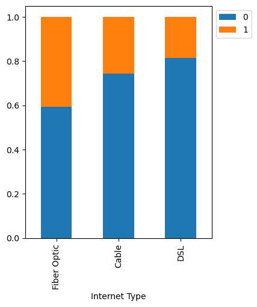

```python
stacked_barplot(df_customer, "Internet Type", "Churn")
```

### **Interpretations**

**1. Overall Summary**

The total dataset contains 5,517 customers with three types of internet services:

- **Fiber Optic:** The majority (3,035 customers) use Fiber Optic internet.
- **DSL (Digital Subscriber Line):** 1,652 customers use DSL.
- **Cable:** 830 customers use Cable internet.

**2. Churn Rates by Internet Type**

- **Fiber Optic:**
  - **1,236 churned** (40.7% of Fiber Optic users).
  - **1,799 stayed** (59.3% of Fiber Optic users).
  - Fiber Optic shows the highest churn percentage among the three internet types, suggesting potential dissatisfaction or higher costs associated with this service. It could also reflect that Fiber Optic users might have more alternatives available.
- **DSL:**
  - **307 churned** (18.6% of DSL users).
  - **1,345 stayed** (81.4% of DSL users).
  - DSL users have the lowest churn percentage, potentially indicating more satisfaction or fewer competing options available for these customers.
- **Cable:**
  - **213 churned** (25.7% of Cable users).
  - **617 stayed** (74.3% of Cable users).
  - Cable internet has a moderate churn rate, falling between DSL and Fiber Optic.

**3. Insights and Patterns**

- **High Churn in Fiber Optic Users:**
  - Fiber Optic users make up the majority of churners (1,236 out of 1,756 total churners, or about 70.4%).
  - This high churn rate may indicate dissatisfaction with pricing, reliability, or the availability of competitive offers from other providers.
- **DSL Retains Most Customers:**
  - DSL users have the highest retention rate (81.4%), suggesting it might be more reliable, cost-effective, or preferred in areas with fewer alternative options.
  - Customers with DSL may also be more likely to stay due to the lack of infrastructure for newer technologies in their regions.
- **Moderate Churn in Cable Users:**
  - The churn percentage (25.7%) suggests that Cable is somewhat competitive but not as sticky as DSL. Customers may switch to higher-speed Fiber Optic or other alternatives if available.

**4. Business Implications**

- **Focus on Fiber Optic Customers:**
  - With the highest churn rate, strategies should be developed to improve retention for Fiber Optic users.
  - Consider offering loyalty discounts, better customer service, or value-added services to retain these high-risk customers.
- **Leverage DSL's Strength:**
  - Since DSL users have the lowest churn rate, this customer base represents a stronghold for the business. Emphasize retention strategies and upselling opportunities here.
- **Evaluate Cable Customer Needs:**
  - Address the moderately high churn in Cable users by identifying their pain points. Offering competitive packages or bundling Cable with additional services may help retain these customers.

**5. Key Questions for Further Exploration**

- What are the main reasons for churn among Fiber Optic users? Is it price, service quality, or competition?
- Are DSL users less likely to churn because of regional limitations or pricing advantages?
- How does churn in Cable users differ geographically or demographically?

**By addressing these patterns, targeted strategies can help reduce churn and improve customer retention across different Internet types.**

### **4. Churn vs. Offer**

```
Churn       0    1   All
Offer
All      2348  818  3166
Offer E   379  426   805
Offer D   441  161   602
Offer B   723  101   824
Offer C   320   95   415
Offer A   485   35   520
------------------------------------------------------------------------------------------------------------------------
```

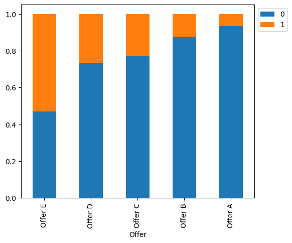

```python
stacked_barplot(df_customer, "Offer", "Churn")
```

### **Interpretations**

**1. Overall Summary**

The dataset contains **3,166** customers who subscribed to specific promotional offers (Offer A, B, C, D, or E). Among them:

- **2,348 customers did not churn** (74.2%).
- **818 customers churned** (25.8%).

**3. Insights and Patterns**

- **a. Offer E is Associated with High Churn:**
  - Over half of the customers subscribed to Offer E churned (52.9%). This suggests potential dissatisfaction with the offer’s terms or post-offer services.
  - It's critical to investigate why Offer E has a poor retention rate. Is it due to pricing, insufficient benefits, or unmet customer expectations?
- **b. Offers A and B Perform Best:**
  - Both Offer A and Offer B have the lowest churn rates, with 6.7% and 12.3% churn, respectively.
  - These offers might provide higher value, better meet customer needs, or be more effectively targeted at the right audience.
- **c. Moderate Churn in Offers C and D:**
  - Offers C and D have churn rates of 22.9% and 26.7%, respectively. These rates are acceptable but suggest room for improvement in terms of retention strategies.
- **d. Disparity Between Offers:**
  - The stark contrast between the churn rates of Offer E (52.9%) and Offer A (6.7%) highlights significant differences in the success of various promotional strategies.

**4. Business Implications**

- **Investigate Offer E:**
  - Conduct surveys or interviews with customers who churned after subscribing to Offer E. Identify the key drivers of dissatisfaction and adjust the offer terms, benefits, or pricing accordingly.
- **Replicate Success of Offers A and B:**
  - Analyze what makes Offer A and Offer B effective. Consider expanding these offers or using similar strategies for other promotional campaigns.
- **Optimize Offers C and D:**
  - Identify ways to enhance the perceived value of Offers C and D, such as by bundling services, extending benefits, or improving communication about the offer's terms.
- **Target High-Churn Offers Strategically:**
  - Use targeted retention strategies for customers subscribed to Offer E. For instance, proactively engage with them before their churn decision, offering discounts, extended benefits, or loyalty rewards.

**5. Key Questions for Further Exploration**

- What differentiates the customer profiles for Offer A (low churn) vs. Offer E (high churn)?
- How does customer churn vary by tenure, payment method, or internet type within each offer?
- Are customers who churned from Offer E moving to competitors, and if so, why?

**By understanding and addressing these patterns, the company can refine its promotional strategies to improve customer retention and maximize long-term revenue.**

# **Handling the missing values:**

```python
# Conserving a copy of the dataframe "df_customer"
df_customer_orig = df_customer.copy()
```

```python
# Let's check for missing values in the data
round(df_customer.isnull().sum() / df_customer.isnull().count() * 100, 2)
```

```
Age                                   0.00
Avg Monthly GB Download               0.00
Avg Monthly Long Distance Charges     0.00
Churn Category                       73.46
Churn Reason                         73.46
Churn Score                           0.00
City                                  0.00
CLTV                                  0.00
Contract                              0.00
Country                               0.00
Customer ID                           0.00
Customer Status                       0.00
Dependents                            0.00
Device Protection Plan                0.00
Gender                                0.00
Internet Service                      0.00
Internet Type                        21.67
Lat Long                              0.00
Latitude                              0.00
Longitude                             0.00
Married                               0.00
Monthly Charge                        0.00
Multiple Lines                        0.00
Number of Dependents                  0.00
Number of Referrals                   0.00
Offer                                55.05
Online Backup                         0.00
Online Security                       0.00
Paperless Billing                     0.00
Partner                               0.00
Payment Method                        0.00
Phone Service                         0.00
Population                            0.00
Premium Tech Support                  0.00
Quarter                               0.00
Referred a Friend                     0.00
Satisfaction Score                    0.00
Senior Citizen                        0.00
State                                 0.00
Streaming Movies                      0.00
Streaming Music                       0.00
Streaming TV                          0.00
Tenure in Months                      0.00
Total Charges                         0.00
Total Extra Data Charges              0.00
Total Long Distance Charges           0.00
Total Refunds                         0.00
Total Revenue                         0.00
Under 30                              0.00
Unlimited Data                        0.00
Zip Code                              0.00
Churn                                 0.00
dtype: float64
```

**4 columns have missing values:**

- Churn Category (73.46%).
- Churn Reason (73.46%).
- Internet Type (21.67%).
- Offer (55.05%).

### **1. Internet Type:**

This is a categorical feature representing the type of internet connection customers use (e.g., DSL, Fiber Optic, Cable). Missing values could imply that the customer might not use internet services at all.

```python
# Filling the missing values with 'No Internet' category
df_customer['Internet Type'] = df_customer['Internet Type'].fillna('No Internet')
```

### **2. Offer:**

This is a categorical feature representing promotional offers provided to customers (e.g., Offer A, Offer B, etc.). Missing values could indicate that the customer might not have availed of any offer.

```python
# Filling the missing values with 'No Offer' category
df_customer['Offer'] = df_customer['Offer'].fillna('No Offer')
```

### **3. Churn Category and Churn Reason:**

```python
# Fill missing values in 'Churn Category' and 'Churn Reason'
for feature in ['Churn Category', 'Churn Reason']:
    # Non-churned customers
    df_customer.loc[df_customer['Churn'] == 0, feature] = df_customer.loc[df_customer['Churn'] == 0, feature].fillna('Not Applicable')

    # Churned customers
    mode_value = df_customer.loc[df_customer['Churn'] == 1, feature].mode()[0]  # Get mode for churned customers
    df_customer.loc[df_customer['Churn'] == 1, feature] = df_customer.loc[df_customer['Churn'] == 1, feature].fillna(mode_value)
```

### **4. Verify Missing Values:**

After applying the imputation strategy, check for remaining missing values:

```python
print(df_customer[['Churn Category', 'Churn Reason', 'Internet Type', 'Offer']].isnull().sum())
```

```
Churn Category    0
Churn Reason      0
Internet Type     0
Offer             0
dtype: int64
```

**There are no missing values now.**

# **Feature Engineering:**

## **1. Interaction and Aggregate Features**

**Why use interaction and aggregate features?**

- **Reveal Relationships:** Helps capture hidden dependencies between features that are not obvious when features are used independently.
- **Improve Model Performance:** Interaction and aggregate features often increase the predictive power of machine learning models by reducing bias.
- **Enhance Interpretability:** Some newly created features might make more intuitive sense to stakeholders.

#### **Interaction features**

Interaction features are created by combining two or more features to capture relationships between them. This is particularly useful when the individual features do not explain enough variability but their combination does.

```python
# Interaction features
# Multiply numerical features
df_customer['Cumulative_Spending'] = df_customer['Monthly Charge'] * df_customer['Tenure in Months']

# Combine categorical features
df_customer['Contract_PaymentMethod'] = df_customer['Contract'] + "_" + df_customer['Payment Method']

# Create a proportional relationship
df_customer['Avg_Spending_Per_Month'] = df_customer['Total Charges'] / (df_customer['Tenure in Months'] + 1)  # Avoid division by zero
```

#### **Aggregate features**

Aggregate features summarize data over time or groups, providing a higher-level view. These are useful for extracting trends or capturing broader insights from related data.

```python
# Aggregation features
# Fill missing Total Charges using Monthly Charges * Tenure
df_customer['Total Charges'] = df_customer['Total Charges'].fillna(df_customer['Monthly Charge'] * df_customer['Tenure in Months'])

# Feature 1: Average Monthly Charge
df_customer['Average Monthly Charge'] = df_customer['Total Charges'] / df_customer['Tenure in Months']

# Feature 2: Revenue Category (e.g., High/Medium/Low Revenue Customers)
df_customer['Revenue Category'] = pd.qcut(df_customer['Total Charges'], q = 3, labels = ['Low', 'Medium', 'High'])

# Feature 3: Mean Monthly Charges by Internet Type
mean_monthly_by_internet = df_customer.groupby('Internet Type')['Monthly Charge'].mean()
df_customer['Mean Monthly Charge (Internet Type)'] = df_customer['Internet Type'].map(mean_monthly_by_internet)
```

#### **Practical Considerations**

**1. Correlation Analysis:**

- Check for multicollinearity between features to avoid redundant or highly correlated new features.

**2. Scaling and Transformation:**

- Scale interaction features to prevent large magnitudes from dominating in models (e.g., standardization or normalization).

**3. Domain Knowledge:**

- Use domain-specific insights to define meaningful combinations (e.g., bundling Internet Type with Contract might reflect customer preferences).

**4. Feature Selection:**

- Use methods like feature importance (from tree-based models) or statistical tests to keep only impactful features.

## **2. Behavioral Features**

The behavioral features can significantly enhance the churn analysis and prediction models by providing deeper insights into customer behavior and preferences.

#### **Usage Patterns (Internet Type and Spending Habits)**

Combine the Internet Type with customer spending habits (Monthly Charges and Total Charges) to create insights about usage patterns.

```python
# Combine Internet Type and Monthly Spending
df_customer['InternetType_SpendingCategory'] = df_customer['Internet Type'] + "_" + pd.cut(
                           df_customer['Monthly Charge'],
                           bins = [0, 50, 100, 200],
                           labels = ["Low", "Medium", "High"]).astype('object')

# Combine Internet Type and Total Charges (e.g., High-Spenders on Fiber Optic)
df_customer['InternetType_TotalSpendingCategory'] = df_customer['Internet Type'] + "_" + pd.cut(
                          df_customer['Total Charges'],
                          bins = [0, 2000, 5000, 9000],
                          labels = ["Low", "Medium", "High"]).astype('object')
```

#### **Payment Method and Contract Interaction**

Combine Payment Method and Contract to create a new feature that identifies risky combinations (e.g., short-term contracts with manual payments).

```python
# Combine Payment Method and Contract
df_customer['Payment_Contract_Interaction'] = df_customer['Payment Method'] + "_" + df_customer['Contract']

# Optional: Create a high-risk indicator
# For example, if the combination is Month-to-Month contract + Mailed Check
df_customer['High_Risk_Indicator'] = ((df_customer['Contract'] == "Month-to-Month") &
                             (df_customer['Payment Method'] == "Mailed Check")).astype(int)
```

#### **Explanation**

**1. Usage Patterns:**

- Identify specific patterns like "Fiber Optic_High spenders" who might be loyal customers due to satisfaction with high-speed internet.
- Understand low-spending DSL customers who may be at a higher risk of churn.

**2. Payment Method & Contract Interaction:**

- Highlight risky combinations like "Month-to-Month contracts with Mailed Check" as they correlate with higher churn risk.
- Identify safer combinations like "Two-Year contracts with Bank Withdrawal."

## **3. Temporal Features**

These features can be instrumental in understanding customer behavior over time and building predictive models.

#### **Time Since Joining**

This feature compares the customer's Tenure in Months with the duration since their account was first activated.

```python
from datetime import datetime, timedelta

# Assume a snapshot date (e.g., last data of the last update of the database)
snapshot_date = datetime(2024, 6, 25)

# Calculate approximate start date
df_customer['Start Date'] = snapshot_date - pd.to_timedelta(df_customer['Tenure in Months'] * 30, unit='D')

# Convert Start Date to datetime
df_customer['Start Date'] = pd.to_datetime(df_customer['Start Date'])

# Calculate Time Since Joining (in months)
current_date = datetime.now()
df_customer['Time Since Joining (Months)'] = ((current_date - df_customer['Start Date']).dt.days / 30).astype(int)
```

#### **Churned During Contract?**

This feature checks if a churned customer left before completing their contract term.

```python
# Create a column for contract duration in months
# Map contract types to their respective lengths in months
contract_length_map = {
    'Month-to-Month': 1,
    'One Year': 12,
    'Two Year': 24
}

# Create a new column for contract length
df_customer['Contract Length (Months)'] = df_customer['Contract'].map(contract_length_map)

# Create a flag to check if churned during contract
df_customer['Churned During Contract'] = ((df_customer['Churn'] == 1) &
                                  (df_customer['Tenure in Months'] < df_customer['Contract Length (Months)'])).astype(int)
```

#### **Explanation**

**1. Time Since Joining:**

- This feature helps analyze whether long-term customers are more likely to churn or stay.
- A higher value might indicate loyalty, while a sudden churn for customers with long tenure may suggest dissatisfaction.

**2. Churned During Contract?:**

- Customers who churn during their contract term may be dissatisfied with service quality, pricing, or terms.
- This flag can help identify trends for churn that occur prematurely within specific contract types.

## **4. Customer Engagement Features**

These features can be added to the dataset for downstream analysis or predictive modeling.

#### **1. Offer Utilization**

This feature checks if customers are utilizing the offered services. For example, if a customer subscribes to premium offers or add-ons but isn't actively using them, it might indicate disengagement.

```python
df_customer.head(2)
```

|  | Age | Avg Monthly GB Download | Avg Monthly Long Distance Charges | Churn Category | Churn Reason | Churn Score | City | CLTV | Contract | Country | Customer ID | Customer Status | Dependents | Device Protection Plan | Gender | Internet Service | Internet Type | Lat Long | Latitude | Longitude | Married | Monthly Charge | Multiple Lines | Number of Dependents | Number of Referrals | Offer | Online Backup | Online Security | Paperless Billing | … |
| --- | --- | --- | --- | --- | --- | --- | --- | --- | --- | --- | --- | --- | --- | --- | --- | --- | --- | --- | --- | --- | --- | --- | --- | --- | --- | --- | --- | --- | --- | --- |
| 0 | 72 | 4 | 19.44 | Not Applicable | Not Applicable | 51 | San Mateo | 4849 | Two Year | United States | 4526-ZJJTM | Stayed | 0 | 1 | Female | 1 | Fiber Optic | 37.538309, -122.305109 | 37.538309 | -122.305109 | 1 | 88.4 | 0 | 0 | 1 | No Offer | 1 | 0 | 0 | … |
| 1 | 27 | 59 | 45.62 | Not Applicable | Not Applicable | 27 | Sutter Creek | 3715 | Month-to-Month | United States | 5302-BDJNT | Stayed | 0 | 1 | Male | 1 | Fiber Optic | 38.432145, -120.77069 | 38.432145 | -120.770690 | 0 | 95.5 | 1 | 0 | 0 | No Offer | 0 | 0 | 0 | … |

```python
# List of premium service features
premium_services = [
    'Streaming TV',
    'Streaming Movies',
    'Streaming Music',
    'Online Security',
    'Online Backup',
    'Device Protection Plan',
    'Premium Tech Support'
]

# Convert "Yes" to 1 and "No" or "No internet service" to 0
#for service in premium_services:
#    df_customer[service] = df_customer[service].map({'Yes': 1, 'No': 0, 'No internet service': 0})

# Create a feature for the total number of premium services used
df_customer['Total Premium Services'] = df_customer[premium_services].sum(axis=1)

# Create a feature for offer utilization
df_customer['Offer Utilization Rate'] = df_customer['Total Premium Services'] / df_customer['Tenure in Months']
df_customer['Offer Utilization Rate'] = df_customer['Offer Utilization Rate'].fillna(0)  # Fill NaN if tenure is 0

# Example: Flag for underutilization (threshold can be adjusted)
df_customer['Underutilized Offer'] = df_customer['Offer Utilization Rate'] < 0.5
```

#### **2. Service Complaints**

This feature uses information like "Churn Reason" or "Churn Category" to identify customers at risk of churn due to dissatisfaction.

```python
# Feature: Flag for complaints due to dissatisfaction
df_customer['Service Complaint Flag'] = df_customer['Churn Reason'].apply(
                                        lambda x: 1 if x in ['Dissatisfaction', 'Service'] else 0)

# Feature: Aggregated Dissatisfaction Flag
df_customer['Overall Complaint Flag'] = df_customer.apply(
                              lambda row: 1 if row['Churn Reason'] in ['Dissatisfaction', 'Price', 'Competitor'] or
                                 row['Churn Category'] in ['Service', 'Billing', 'Competitor'] else 0, axis=1)
```

#### **Key Insights**

**1. Offer Utilization:**

- Customers with low utilization rates (Underutilized Offer = True) might need targeted engagement strategies (e.g., personalized offers or better onboarding).

**2. Service Complaints:**

- Customers flagged by Service Complaint Flag or Overall Complaint Flag are likely at risk of churn due to dissatisfaction. Proactive support or discounts may help retain them.

## **5. Churn Propensity Features**

#### **1. Historical Patterns: Rolling Averages and Trends**

This feature creates rolling averages or trends for churn likelihood based on features like Monthly Charges, Tenure, or Customer Status.

```python
# Sort by 'Start Date' to calculate rolling trends
df_customer = df_customer.sort_values('Start Date')

# Feature 1: Rolling average of Monthly Charges
df_customer['Rolling Avg Monthly Charges'] = df_customer['Monthly Charge'].rolling(window=3, min_periods=1).mean()

# Feature 2: Trend of Tenure (rate of increase over months)
df_customer['Tenure Growth Rate'] = df_customer['Tenure in Months'].diff() / df_customer['Tenure in Months'].shift(1)
df_customer['Tenure Growth Rate'] = df_customer['Tenure Growth Rate'].fillna(0)  # Replace NaN for the first record

# Feature 3: Historical Churn Rate (rolling average churn)
df_customer['Rolling Churn Rate'] = df_customer['Churn'].rolling(window=3, min_periods=1).mean()
```

#### **2. Likelihood Scores**

This feature uses past data to predict churn likelihood. Here, we'll use a simplified example of assigning churn probabilities using historical data and machine learning.

```python
#from sklearn.ensemble import RandomForestClassifier
#from sklearn.model_selection import train_test_split
#from sklearn.preprocessing import MinMaxScaler

# Split df_customer_orig into features and target
#X = df_customer_orig.drop(columns=["Churn"], axis=1)
#Y = df_customer_orig["Churn"]

# Normalize features for better performance
#scaler = MinMaxScaler()
#X_scaled = scaler.fit_transform(X)

# Train-test split
#X_train, X_test, y_train, y_test = train_test_split(X_scaled, y, test_size=0.2, random_state=42)

# Train a simple Random Forest Classifier
#rf_model = RandomForestClassifier(random_state=42)
#rf_model.fit(X_train, y_train)

# Predict churn likelihood
#df['Churn Likelihood Score'] = rf_model.predict_proba(X_scaled)[:, 1]  # Probability of churn
```

#### **Key Insights**

**1. Historical Patterns:**

- Rolling averages (e.g., Monthly Charges) reveal trends in customer behavior.
- Churn rate trends highlight periods of higher churn risks.

**2. Likelihood Scores:**

- Churn Likelihood Score gives a probability estimate of churn risk, enabling more targeted interventions.
- Scores can be used as a feature in a more advanced deep learning model.

## **6. Customer Demographics Features**

These engineered features can be added to the dataset and fed into machine learning or deep learning models to enhance prediction accuracy.

#### **1. Group Similar Customers by City, State, or Region**

This involves clustering customers based on their demographic information (e.g., city, state, or region). We can use Label Encoding or One-Hot Encoding to prepare these features for analysis.

```python
#from sklearn.preprocessing import LabelEncoder, OneHotEncoder

# Group customers by Region using Label Encoding
#label_encoder = LabelEncoder()
#df_customer['Region Group (Encoded)'] = label_encoder.fit_transform(df_customer['Region'])

# One-Hot Encoding for more granular information
#df_one_hot = pd.get_dummies(df_customer[['City', 'State', 'Region']], drop_first=True)

# Combine the one-hot encoded data with the original DataFrame
#df_customer = pd.concat([df_customer, df_one_hot], axis=1)
```

#### **2. Latitudinal/Longitudinal Information**

Using latitude and longitude, we can engineer features like proximity to company headquarters or service hubs using Haversine Distance.

```python
# Function to calculate Haversine Distance
#def haversine_distance(lat1, lon1, lat2, lon2):
#    R = 6371  # Radius of the Earth in km
#    lat1, lon1, lat2, lon2 = map(np.radians, [lat1, lon1, lat2, lon2])
#    dlat = lat2 - lat1
#    dlon = lon2 - lon1
#    a = np.sin(dlat/2)**2 + np.cos(lat1) * np.cos(lat2) * np.sin(dlon/2)**2
#    c = 2 * np.arctan2(np.sqrt(a), np.sqrt(1-a))
#    return R * c

# Calculate distance from HQ for each customer
#df_customer['Distance to HQ (km)'] = df_customer.apply(
#    lambda row: haversine_distance(row['Latitude'], row['Longitude'], row['HQ Latitude'], row['HQ Longitude']),
#    axis=1)
```

#### **Key Insights**

- **1. Group Similar Customers:**
  - By grouping or encoding customers based on their geographic data, we can identify regional churn patterns.
  - For example, a region might have higher churn due to service availability or customer satisfaction.
- **2. Latitudinal/Longitudinal Information:**
  - Proximity to HQ or service hubs can indicate ease of support or service delivery.
  - Customers farther away may have higher churn rates due to perceived service inefficiencies.

## **Creating Dummy Variables for the categorical features**

#### **Check the non-numerical variables in the df_customer dataset.**

```python
# Select columns that are NOT of numerical type
non_numerical_columns = df_customer.select_dtypes(exclude=['number']).columns.tolist()
print(non_numerical_columns)
print(len(non_numerical_columns))
```

```
['Churn Category', 'Churn Reason', 'City', 'Contract', 'Country', 'Customer ID', 'Customer Status', 'Gender', 'Internet Type', 'Lat Long', 'Offer', 'Payment Method', 'Quarter', 'State', 'Contract_PaymentMethod', 'Revenue Category', 'InternetType_SpendingCategory', 'InternetType_TotalSpendingCategory…
21
```

```python
# check for unique values of features
for i in non_numerical_columns:
    print("Unique values in", i, "are :")
    print(df_customer[i].value_counts())
    print("number of unique categories:  ", df_customer[i].nunique())
    print("*" * 50)
```

```
Unique values in Churn Category are :
Churn Category
Not Applicable     5174
Competitor          841
Attitude            314
Dissatisfaction     303
Price               211
Other               200
Name: count, dtype: int64
number of unique categories:   6
Unique values in Churn Reason are :
Churn Reason
Not Applicable                               5174
Competitor had better devices                 313
Competitor made better offer                  311
Attitude of support person                    220
Don't know                                    130
Competitor offered more data                  117
Competitor offered higher download speeds     100
Attitude of service provider                   94
Price too high                                 78
Product dissatisfaction                        77
Network reliability                            72
Long distance charges                          64
Service dissatisfaction                        63
Moved                                          46
Extra data charges                             39
Limited range of services                      37
Poor expertise of online support               31
Lack of affordable download/upload speed       30
Lack of self-service on Website                29
Poor expertise of phone support                12
Deceased                                        6
Name: count, dtype: int64
number of unique categories:   21
Unique values in City are :
City
Los Angeles         293
San Diego           285
San Jose            112
```

[output cut: 166 more lines]

```
2024-02-26    176
             ...
2021-05-12     59
2022-03-08     57
2021-04-12     56
2020-11-13     51
2021-07-11     50
Name: count, Length: 72, dtype: int64
number of unique categories:   72
Unique values in Underutilized Offer are :
Underutilized Offer
True     6402
False     641
Name: count, dtype: int64
number of unique categories:   2
```

#### **Dropping unnecessary or irrelevant features can improve model performance by eliminating noise.**

```python
# conserving a copy of the df_customer
df_customer_copy = df_customer.copy()

# Dropping the following columns : "City", "Country", "Customer ID", "Lat Long", "Quarter", "State", "Underutilized Offer", "Start Date"
df_customer = df_customer.drop(columns=["City", "Country", "Customer ID", "Lat Long", "Quarter", "State","Underutilized Offer",
                                            "Start Date", "Latitude", "Longitude", "Population", "Zip Code"], axis=1)
```

```python
# Checking the new shape of the dataset
df_customer.shape
```

```
(7043, 62)
```

#### **List of the categorical features to dummy.**

```python
List_cat_feat = ['Churn Category', 'Churn Reason', 'Contract', 'Customer Status', 'Gender', 'Internet Type', 'Offer',
                 'Payment Method', 'Contract_PaymentMethod', 'Revenue Category', 'Payment_Contract_Interaction',
                 'InternetType_SpendingCategory', 'InternetType_TotalSpendingCategory']
```

#### **Creating dummy variables: binary columns for each unique category**

It's generally a good practice to eliminate one of the dummied variables when preparing data for deep learning models. This helps to avoid multicollinearity (redundant features) and ensures that the model can learn from the reduced set of features without introducing unnecessary noise.

```python
# Create dummy variables for the 'type' column
Churn_Category_dummies = pd.get_dummies(df_customer['Churn Category'], prefix='Churn_Category', prefix_sep = ':', drop_first=True)
Churn_Reason_dummies = pd.get_dummies(df_customer['Churn Reason'], prefix='Churn_Reason', prefix_sep = ':', drop_first=True)
Contract_dummies = pd.get_dummies(df_customer['Contract'], prefix='Contract', prefix_sep = ':', drop_first=True)
Customer_Status_dummies = pd.get_dummies(df_customer['Customer Status'], prefix='Customer_Status', prefix_sep = ':', drop_first=True)
Gender_dummies = pd.get_dummies(df_customer['Gender'], prefix='Gender', prefix_sep = ':', drop_first=True)
Internet_Type_dummies = pd.get_dummies(df_customer['Internet Type'], prefix='Internet_Type', prefix_sep = ':', drop_first=True)
Offer_dummies = pd.get_dummies(df_customer['Offer'], prefix='Offer', prefix_sep = ':', drop_first=True)
Payment_Method_dummies = pd.get_dummies(df_customer['Payment Method'], prefix='Payment_Method', prefix_sep = ':', drop_first=True)
Contract_PaymentMethod_dummies = pd.get_dummies(df_customer['Contract_PaymentMethod'], prefix='Contract_PaymentMethod', prefix_sep = ':', drop_first=True)
Revenue_Category_dummies = pd.get_dummies(df_customer['Revenue Category'], prefix='Revenue_Category', prefix_sep = ':', drop_first=True)
Payment_Contract_Interaction_dummies = pd.get_dummies(df_customer['Payment_Contract_Interaction'], prefix='Payment_Contract_Interaction', prefix_sep = ':', drop_first=True)
InternetType_SpendingCategory_dummies = pd.get_dummies(df_customer['InternetType_SpendingCategory'], prefix='InternetType_SpendingCategory', prefix_sep = ':', drop_first=True)
InternetType_TotalSpendingCategory_dummies = pd.get_dummies(df_customer['InternetType_TotalSpendingCategory'], prefix='InternetType_TotalSpendingCategory', prefix_sep = ':', drop_first=True)
```

#### **Concatinate the dummied variables with the dataframe df_customer.**

```python
df_customer = pd.concat([df_customer, Churn_Category_dummies, Churn_Reason_dummies, Contract_dummies, Customer_Status_dummies, Gender_dummies,
                 Internet_Type_dummies, Offer_dummies, Payment_Method_dummies, Contract_PaymentMethod_dummies, Revenue_Category_dummies,
                 Payment_Contract_Interaction_dummies, InternetType_SpendingCategory_dummies, InternetType_TotalSpendingCategory_dummies], axis=1)
```

#### **Dropping the original features**

```python
df_customer = df_customer.drop(columns = List_cat_feat, axis=1)
```

```python
df_customer.head()
```

|  | Age | Avg Monthly GB Download | Avg Monthly Long Distance Charges | Churn Score | CLTV | Dependents | Device Protection Plan | Internet Service | Married | Monthly Charge | Multiple Lines | Number of Dependents | Number of Referrals | Online Backup | Online Security | Paperless Billing | Partner | Phone Service | Premium Tech Support | Referred a Friend | Satisfaction Score | Senior Citizen | Streaming Movies | Streaming Music | Streaming TV | Tenure in Months | Total Charges | Total Extra Data Charges | Total Long Distance Charges | … |
| --- | --- | --- | --- | --- | --- | --- | --- | --- | --- | --- | --- | --- | --- | --- | --- | --- | --- | --- | --- | --- | --- | --- | --- | --- | --- | --- | --- | --- | --- | --- |
| 3533 | 61 | 22 | 0.00 | 32 | 6107 | 1 | 1 | 1 | 1 | 63.80 | 0 | 3 | 8 | 1 | 1 | 1 | 1 | 0 | 1 | 1 | 4 | 0 | 1 | 1 | 1 | 72 | 4684.30 | 0 | 0.00 | … |
| 1387 | 78 | 30 | 14.94 | 71 | 4008 | 0 | 1 | 1 | 0 | 117.35 | 1 | 0 | 0 | 1 | 1 | 1 | 0 | 1 | 1 | 0 | 4 | 1 | 1 | 1 | 1 | 72 | 8436.25 | 0 | 1075.68 | … |
| 5854 | 56 | 30 | 0.00 | 27 | 5092 | 0 | 1 | 1 | 1 | 65.20 | 0 | 0 | 5 | 1 | 1 | 1 | 1 | 0 | 1 | 1 | 3 | 0 | 1 | 1 | 1 | 72 | 4784.45 | 0 | 0.00 | … |
| 1393 | 57 | 30 | 10.97 | 62 | 6450 | 0 | 1 | 1 | 1 | 85.95 | 1 | 0 | 2 | 1 | 0 | 0 | 1 | 1 | 1 | 1 | 4 | 0 | 1 | 1 | 1 | 72 | 6151.90 | 0 | 789.84 | … |
| 2999 | 66 | 22 | 32.37 | 69 | 6072 | 0 | 0 | 1 | 1 | 78.50 | 1 | 0 | 4 | 0 | 1 | 0 | 1 | 1 | 0 | 1 | 3 | 1 | 0 | 0 | 0 | 72 | 5602.25 | 0 | 2330.64 | … |

```python
df_customer.shape
```

```
(7043, 124)
```

**There are now 124 features in the dataset.**

## **Lest's convert Boolean Variables (True and False) to Binary ones (0 and 1)**

```python
# get the list of all the feature names
df_customer.columns.tolist()
```

```
['Age',
 'Avg Monthly GB Download',
 'Avg Monthly Long Distance Charges',
 'Churn Score',
 'CLTV',
 'Dependents',
 'Device Protection Plan',
 'Internet Service',
 'Married',
 'Monthly Charge',
 'Multiple Lines',
 'Number of Dependents',
 'Number of Referrals',
 'Online Backup',
 'Online Security',
 'Paperless Billing',
 'Partner',
 'Phone Service',
 'Premium Tech Support',
 'Referred a Friend',
 'Satisfaction Score',
 'Senior Citizen',
 'Streaming Movies',
 'Streaming Music',
 'Streaming TV',
 'Tenure in Months',
 'Total Charges',
 'Total Extra Data Charges',
 'Total Long Distance Charges',
 'Total Refunds',
 'Total Revenue',
 'Under 30',
 'Unlimited Data',
 'Churn',
 'Cumulative_Spending',
 'Avg_Spending_Per_Month',
 'Average Monthly Charge',
 'Mean Monthly Charge (Internet Type)',
 'High_Risk_Indicator',
 'Time Since Joining (Months)',
```

[output cut: 69 more lines]

```
 'InternetType_SpendingCategory:DSL_Low',
 'InternetType_SpendingCategory:DSL_Medium',
 'InternetType_SpendingCategory:Fiber Optic_High',
 'InternetType_SpendingCategory:Fiber Optic_Medium',
 'InternetType_SpendingCategory:No Internet_Low',
 'InternetType_TotalSpendingCategory:Cable_Low',
 'InternetType_TotalSpendingCategory:Cable_Medium',
 'InternetType_TotalSpendingCategory:DSL_High',
 'InternetType_TotalSpendingCategory:DSL_Low',
 'InternetType_TotalSpendingCategory:DSL_Medium',
 'InternetType_TotalSpendingCategory:Fiber Optic_High',
 'InternetType_TotalSpendingCategory:Fiber Optic_Low',
 'InternetType_TotalSpendingCategory:Fiber Optic_Medium',
 'InternetType_TotalSpendingCategory:No Internet_Low',
 'InternetType_TotalSpendingCategory:No Internet_Medium']
```

```python
# List of columns to convert
columns_to_convert = ['Churn_Category:Competitor',
 'Churn_Category:Dissatisfaction',
 'Churn_Category:Not Applicable',
 'Churn_Category:Other',
 'Churn_Category:Price',
 'Churn_Reason:Attitude of support person',
 'Churn_Reason:Competitor had better devices',
 'Churn_Reason:Competitor made better offer',
 'Churn_Reason:Competitor offered higher download speeds',
 'Churn_Reason:Competitor offered more data',
 'Churn_Reason:Deceased',
 "Churn_Reason:Don't know",
 'Churn_Reason:Extra data charges',
 'Churn_Reason:Lack of affordable download/upload speed',
 'Churn_Reason:Lack of self-service on Website',
 'Churn_Reason:Limited range of services',
 'Churn_Reason:Long distance charges',
 'Churn_Reason:Moved',
 'Churn_Reason:Network reliability',
 'Churn_Reason:Not Applicable',
 'Churn_Reason:Poor expertise of online support',
 'Churn_Reason:Poor expertise of phone support',
 'Churn_Reason:Price too high',
 'Churn_Reason:Product dissatisfaction',
 'Churn_Reason:Service dissatisfaction',
 'Contract:One Year',
 'Contract:Two Year',
 'Customer_Status:Joined',
 'Customer_Status:Stayed',
 'Gender:Male',
 'Internet_Type:DSL',
 'Internet_Type:Fiber Optic',
 'Internet_Type:No Internet',
 'Offer:Offer A',
 'Offer:Offer B',
 'Offer:Offer C',
 'Offer:Offer D',
 'Offer:Offer E',
 'Payment_Method:Credit Card',
 'Payment_Method:Mailed Check',
 'Contract_PaymentMethod:Month-to-Month_Credit Card',
 'Contract_PaymentMethod:Month-to-Month_Mailed Check',
 'Contract_PaymentMethod:One Year_Bank Withdrawal',
 'Contract_PaymentMethod:One Year_Credit Card',
 'Contract_PaymentMethod:One Year_Mailed Check',
 'Contract_PaymentMethod:Two Year_Bank Withdrawal',
 'Contract_PaymentMethod:Two Year_Credit Card',
 'Contract_PaymentMethod:Two Year_Mailed Check',
 'Revenue_Category:Medium',
 'Revenue_Category:High',
 'Payment_Contract_Interaction:Bank Withdrawal_One Year',
 'Payment_Contract_Interaction:Bank Withdrawal_Two Year',
 'Payment_Contract_Interaction:Credit Card_Month-to-Month',
 'Payment_Contract_Interaction:Credit Card_One Year',
 'Payment_Contract_Interaction:Credit Card_Two Year',
 'Payment_Contract_Interaction:Mailed Check_Month-to-Month',
 'Payment_Contract_Interaction:Mailed Check_One Year',
 'Payment_Contract_Interaction:Mailed Check_Two Year',
 'InternetType_SpendingCategory:Cable_Low',
 'InternetType_SpendingCategory:Cable_Medium',
 'InternetType_SpendingCategory:DSL_Low',
 'InternetType_SpendingCategory:DSL_Medium',
 'InternetType_SpendingCategory:Fiber Optic_High',
 'InternetType_SpendingCategory:Fiber Optic_Medium',
 'InternetType_SpendingCategory:No Internet_Low',
 'InternetType_TotalSpendingCategory:Cable_Low',
 'InternetType_TotalSpendingCategory:Cable_Medium',
 'InternetType_TotalSpendingCategory:DSL_High',
 'InternetType_TotalSpendingCategory:DSL_Low',
 'InternetType_TotalSpendingCategory:DSL_Medium',
 'InternetType_TotalSpendingCategory:Fiber Optic_High',
 'InternetType_TotalSpendingCategory:Fiber Optic_Low',
 'InternetType_TotalSpendingCategory:Fiber Optic_Medium',
 'InternetType_TotalSpendingCategory:No Internet_Low',
 'InternetType_TotalSpendingCategory:No Internet_Medium']

# Apply conversion to multiple columns
df_customer[columns_to_convert] = df_customer[columns_to_convert].astype('int64')
```

```python
# Let's view the first 5 rows of the data to verify the conversion
df_customer.head()
```

|  | Age | Avg Monthly GB Download | Avg Monthly Long Distance Charges | Churn Score | CLTV | Dependents | Device Protection Plan | Internet Service | Married | Monthly Charge | Multiple Lines | Number of Dependents | Number of Referrals | Online Backup | Online Security | Paperless Billing | Partner | Phone Service | Premium Tech Support | Referred a Friend | Satisfaction Score | Senior Citizen | Streaming Movies | Streaming Music | Streaming TV | Tenure in Months | Total Charges | Total Extra Data Charges | Total Long Distance Charges | … |
| --- | --- | --- | --- | --- | --- | --- | --- | --- | --- | --- | --- | --- | --- | --- | --- | --- | --- | --- | --- | --- | --- | --- | --- | --- | --- | --- | --- | --- | --- | --- |
| 3533 | 61 | 22 | 0.00 | 32 | 6107 | 1 | 1 | 1 | 1 | 63.80 | 0 | 3 | 8 | 1 | 1 | 1 | 1 | 0 | 1 | 1 | 4 | 0 | 1 | 1 | 1 | 72 | 4684.30 | 0 | 0.00 | … |
| 1387 | 78 | 30 | 14.94 | 71 | 4008 | 0 | 1 | 1 | 0 | 117.35 | 1 | 0 | 0 | 1 | 1 | 1 | 0 | 1 | 1 | 0 | 4 | 1 | 1 | 1 | 1 | 72 | 8436.25 | 0 | 1075.68 | … |
| 5854 | 56 | 30 | 0.00 | 27 | 5092 | 0 | 1 | 1 | 1 | 65.20 | 0 | 0 | 5 | 1 | 1 | 1 | 1 | 0 | 1 | 1 | 3 | 0 | 1 | 1 | 1 | 72 | 4784.45 | 0 | 0.00 | … |
| 1393 | 57 | 30 | 10.97 | 62 | 6450 | 0 | 1 | 1 | 1 | 85.95 | 1 | 0 | 2 | 1 | 0 | 0 | 1 | 1 | 1 | 1 | 4 | 0 | 1 | 1 | 1 | 72 | 6151.90 | 0 | 789.84 | … |
| 2999 | 66 | 22 | 32.37 | 69 | 6072 | 0 | 0 | 1 | 1 | 78.50 | 1 | 0 | 4 | 0 | 1 | 0 | 1 | 1 | 0 | 1 | 3 | 1 | 0 | 0 | 0 | 72 | 5602.25 | 0 | 2330.64 | … |

```python
# Check the df_customer info
df_customer.info()
```

```
<class 'pandas.core.frame.DataFrame'>
Index: 7043 entries, 3533 to 3792
Columns: 124 entries, Age to InternetType_TotalSpendingCategory:No Internet_Medium
dtypes: float64(14), int32(3), int64(107)
memory usage: 6.6 MB
```

```python
# Identifuy the features of type 'int32'
df_customer.select_dtypes(exclude=['float64', 'int64']).columns.tolist()
```

```
['High_Risk_Indicator',
 'Time Since Joining (Months)',
 'Churned During Contract']
```

```python
# convert columns of datatype int32 to datatype int64
df_customer[['High_Risk_Indicator', 'Churned During Contract', 'Time Since Joining (Months)']] = df_customer[['High_Risk_Indicator', 'Churned During Contract', 'Time Since Joining (Months)']].astype('int64')
```

```python
# Check the df_customer info
df_customer.info()
```

```
<class 'pandas.core.frame.DataFrame'>
Index: 7043 entries, 3533 to 3792
Columns: 124 entries, Age to InternetType_TotalSpendingCategory:No Internet_Medium
dtypes: float64(14), int64(110)
memory usage: 6.7 MB
```

**There are now in the dataset, 14 features of dtypes: float64, and 110 features of dtypes: int64.**

# **Spliting data to train dataset and test dataset**

```python
## Separating Independent and Dependent Columns
X = df_customer.drop(columns=["Churn"], axis=1)
Y = df_customer["Churn"]
```

```python
# Splitting the dataset into the Training and Testing set.
X_train, X_test, y_train, y_test = train_test_split(X, Y, test_size = 0.2, random_state = 42, stratify = Y)
```

```python
# Checking a sample of 5 entries of y_train
y_train.sample(5)
```

```
4529    1
2077    1
6589    0
4219    0
6181    0
Name: Churn, dtype: int64
```

```python
#Checking the shape of train and test datasets
print(X_train.shape)
print(X_test.shape)
print(y_train.shape)
print(y_test.shape)
```

```
(5634, 123)
(1409, 123)
(5634,)
(1409,)
```

# **Model Building**

## **Feedforward Neural Network (FNN)**

- **Feedforward Neural Network (FNN)**, also called **Multi-Layer Perceptron (MLP)**, is one of the simplest and most commonly used types of artificial neural networks. It is primarily used for supervised learning tasks like **classification** and **regression**.
- FNNs are foundational building blocks in deep learning. While simple, they remain a powerful tool for learning patterns in tabular, time-series, or small-scale data.

```python
# Importing necessary libraries for modeling
import tensorflow as tf
from tensorflow.keras.models import Sequential
from tensorflow.keras.layers import Dense, Dropout
from sklearn.model_selection import train_test_split
from sklearn.preprocessing import StandardScaler
# To get diferent metric scores
from sklearn.metrics import accuracy_score,precision_score,recall_score,f1_score,confusion_matrix,roc_auc_score,classification_report,precision_recall_curve,roc_curve,make_scorer

# Reset the default graph (use compatibility mode)
tf.compat.v1.reset_default_graph()
```

```
WARNING:tensorflow:From C:\Users\pc\AppData\Local\Temp\ipykernel_19844\2520917400.py:11: The name tf.reset_default_graph is deprecated. Please use tf.compat.v1.reset_default_graph instead.
```

```python
backend.clear_session()
#Fixing the seed for random number generators so that we can ensure we receive the same output everytime
np.random.seed(42)
import random
random.seed(42)
tf.random.set_seed(42)
```

```python
# get a list of the feature names
feature_names = list(X.columns.tolist())

# Scale numerical features
scaler = StandardScaler()
X_train_scaled = pd.DataFrame(scaler.fit_transform(X_train), columns=feature_names)
X_test_scaled = pd.DataFrame(scaler.transform(X_test), columns=feature_names)
```

```python
# Define the FNN model
model_FNN = Sequential([
    Dense(128, input_dim = X_train_scaled.shape[1], activation = 'relu'),
    Dropout(0.3),
    Dense(64, activation = 'relu'),
    Dropout(0.3),
    Dense(32, activation = 'relu'),
    Dense(1, activation = 'sigmoid')  # Sigmoid for binary classification
])

# Compile the model
model_FNN.compile(optimizer='adam', loss='binary_crossentropy', metrics=['accuracy'])
```

```python
model_FNN.summary()
```

```
Model: "sequential_1"
```

```
┏━━━━━━━━━━━━━━━━━━━━━━━━━━━━━━━━━━━━━━┳━━━━━━━━━━━━━━━━━━━━━━━━━━━━━┳━━━━━━━━━━━━━━━━━┓
┃ Layer (type)                         ┃ Output Shape                ┃         Param # ┃
┡━━━━━━━━━━━━━━━━━━━━━━━━━━━━━━━━━━━━━━╇━━━━━━━━━━━━━━━━━━━━━━━━━━━━━╇━━━━━━━━━━━━━━━━━┩
│ dense_4 (Dense)                      │ (None, 128)                 │          15,872 │
├──────────────────────────────────────┼─────────────────────────────┼─────────────────┤
│ dropout_2 (Dropout)                  │ (None, 128)                 │               0 │
├──────────────────────────────────────┼─────────────────────────────┼─────────────────┤
│ dense_5 (Dense)                      │ (None, 64)                  │           8,256 │
├──────────────────────────────────────┼─────────────────────────────┼─────────────────┤
│ dropout_3 (Dropout)                  │ (None, 64)                  │               0 │
├──────────────────────────────────────┼─────────────────────────────┼─────────────────┤
│ dense_6 (Dense)                      │ (None, 32)                  │           2,080 │
├──────────────────────────────────────┼─────────────────────────────┼─────────────────┤
│ dense_7 (Dense)                      │ (None, 1)                   │              33 │
└──────────────────────────────────────┴─────────────────────────────┴─────────────────┘
```

```
 Total params: 26,241 (102.50 KB)
```

```
 Trainable params: 26,241 (102.50 KB)
```

```
 Non-trainable params: 0 (0.00 B)
```

```python
# Train the model
history = model_FNN.fit(X_train_scaled, y_train, epochs=30, batch_size=32, validation_data=(X_test_scaled, y_test), verbose=1)
```

```
177/177 ━━━━━━━━━━━━━━━━━━━━ 3s 6ms/step - accuracy: 0.8871 - loss: 0.2846 - val_accuracy: 1.0000 - val_loss: 6.9080e-04
177/177 ━━━━━━━━━━━━━━━━━━━━ 1s 4ms/step - accuracy: 0.9986 - loss: 0.0068 - val_accuracy: 1.0000 - val_loss: 1.8632e-04
177/177 ━━━━━━━━━━━━━━━━━━━━ 1s 4ms/step - accuracy: 0.9999 - loss: 0.0015 - val_accuracy: 1.0000 - val_loss: 5.7085e-05
177/177 ━━━━━━━━━━━━━━━━━━━━ 1s 5ms/step - accuracy: 0.9997 - loss: 9.1269e-04 - val_accuracy: 1.0000 - val_loss: 2.6551e-05
177/177 ━━━━━━━━━━━━━━━━━━━━ 1s 5ms/step - accuracy: 1.0000 - loss: 2.4759e-04 - val_accuracy: 1.0000 - val_loss: 1.8555e-05
177/177 ━━━━━━━━━━━━━━━━━━━━ 1s 4ms/step - accuracy: 1.0000 - loss: 1.8327e-04 - val_accuracy: 1.0000 - val_loss: 9.0492e-06
177/177 ━━━━━━━━━━━━━━━━━━━━ 1s 5ms/step - accuracy: 1.0000 - loss: 8.9963e-05 - val_accuracy: 1.0000 - val_loss: 5.2032e-06
177/177 ━━━━━━━━━━━━━━━━━━━━ 1s 4ms/step - accuracy: 1.0000 - loss: 6.5606e-05 - val_accuracy: 1.0000 - val_loss: 4.4388e-06
177/177 ━━━━━━━━━━━━━━━━━━━━ 1s 5ms/step - accuracy: 0.9998 - loss: 4.0325e-04 - val_accuracy: 1.0000 - val_loss: 6.1160e-06
177/177 ━━━━━━━━━━━━━━━━━━━━ 1s 5ms/step - accuracy: 0.9997 - loss: 5.6823e-04 - val_accuracy: 1.0000 - val_loss: 6.0686e-07
177/177 ━━━━━━━━━━━━━━━━━━━━ 1s 4ms/step - accuracy: 1.0000 - loss: 6.3416e-05 - val_accuracy: 1.0000 - val_loss: 4.8717e-07
177/177 ━━━━━━━━━━━━━━━━━━━━ 1s 4ms/step - accuracy: 1.0000 - loss: 3.7107e-05 - val_accuracy: 1.0000 - val_loss: 3.3838e-07
177/177 ━━━━━━━━━━━━━━━━━━━━ 1s 5ms/step - accuracy: 1.0000 - loss: 3.6930e-05 - val_accuracy: 1.0000 - val_loss: 2.8832e-07
177/177 ━━━━━━━━━━━━━━━━━━━━ 1s 4ms/step - accuracy: 1.0000 - loss: 9.1412e-05 - val_accuracy: 1.0000 - val_loss: 1.1246e-06
177/177 ━━━━━━━━━━━━━━━━━━━━ 1s 5ms/step - accuracy: 1.0000 - loss: 2.5946e-04 - val_accuracy: 1.0000 - val_loss: 3.5879e-07
177/177 ━━━━━━━━━━━━━━━━━━━━ 1s 4ms/step - accuracy: 1.0000 - loss: 1.2591e-05 - val_accuracy: 1.0000 - val_loss: 2.6570e-07
177/177 ━━━━━━━━━━━━━━━━━━━━ 1s 4ms/step - accuracy: 1.0000 - loss: 1.7452e-05 - val_accuracy: 1.0000 - val_loss: 2.5788e-07
177/177 ━━━━━━━━━━━━━━━━━━━━ 1s 4ms/step - accuracy: 1.0000 - loss: 4.2901e-05 - val_accuracy: 1.0000 - val_loss: 9.8788e-08
177/177 ━━━━━━━━━━━━━━━━━━━━ 1s 4ms/step - accuracy: 1.0000 - loss: 4.5528e-06 - val_accuracy: 1.0000 - val_loss: 8.4416e-08
177/177 ━━━━━━━━━━━━━━━━━━━━ 1s 5ms/step - accuracy: 1.0000 - loss: 1.5503e-05 - val_accuracy: 1.0000 - val_loss: 6.1429e-08
177/177 ━━━━━━━━━━━━━━━━━━━━ 1s 5ms/step - accuracy: 1.0000 - loss: 2.9876e-06 - val_accuracy: 1.0000 - val_loss: 5.8443e-08
177/177 ━━━━━━━━━━━━━━━━━━━━ 1s 4ms/step - accuracy: 1.0000 - loss: 1.6685e-05 - val_accuracy: 1.0000 - val_loss: 4.6695e-08
177/177 ━━━━━━━━━━━━━━━━━━━━ 1s 4ms/step - accuracy: 1.0000 - loss: 8.4540e-06 - val_accuracy: 1.0000 - val_loss: 5.3437e-08
177/177 ━━━━━━━━━━━━━━━━━━━━ 1s 5ms/step - accuracy: 1.0000 - loss: 1.6984e-06 - val_accuracy: 1.0000 - val_loss: 4.9831e-08
177/177 ━━━━━━━━━━━━━━━━━━━━ 1s 5ms/step - accuracy: 1.0000 - loss: 4.2643e-06 - val_accuracy: 1.0000 - val_loss: 3.5009e-08
177/177 ━━━━━━━━━━━━━━━━━━━━ 1s 4ms/step - accuracy: 1.0000 - loss: 2.8526e-06 - val_accuracy: 1.0000 - val_loss: 3.0895e-08
177/177 ━━━━━━━━━━━━━━━━━━━━ 1s 4ms/step - accuracy: 1.0000 - loss: 1.7411e-06 - val_accuracy: 1.0000 - val_loss: 2.9248e-08
177/177 ━━━━━━━━━━━━━━━━━━━━ 1s 5ms/step - accuracy: 1.0000 - loss: 1.9400e-06 - val_accuracy: 1.0000 - val_loss: 2.6317e-08
177/177 ━━━━━━━━━━━━━━━━━━━━ 1s 5ms/step - accuracy: 1.0000 - loss: 1.8704e-06 - val_accuracy: 1.0000 - val_loss: 2.2815e-08
177/177 ━━━━━━━━━━━━━━━━━━━━ 1s 4ms/step - accuracy: 1.0000 - loss: 1.5822e-06 - val_accuracy: 1.0000 - val_loss: 1.7048e-08
```

```
45/45 ━━━━━━━━━━━━━━━━━━━━ 0s 3ms/step - accuracy: 1.0000 - loss: 1.4773e-08
```

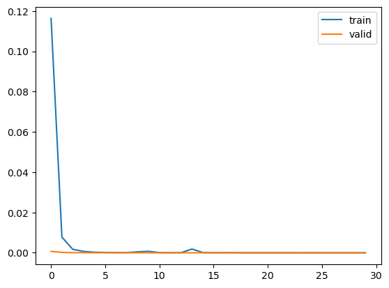

```python
# Capturing learning history per epoch
hist  = pd.DataFrame(history.history)
hist['epoch'] = history.epoch

# Plotting accuracy at different epochs
plt.plot(hist['loss'])
plt.plot(hist['val_loss'])
plt.legend(("train" , "valid") , loc =0)

#Printing results
results = model_FNN.evaluate(X_test_scaled, y_test)
```

### **Metric Function**

Let's create a function to calculate and print the classification report and confusion matrix.

```python
# Creating a function to calculate the confusion matrix
def make_confusion_matrix(cf, group_names=None, categories='auto', count=True, percent=True, cbar=True, xyticks=True,
                          xyplotlabels=True, sum_stats=True, figsize=None, cmap='Blues', title=None):
    '''
    This function will make a pretty plot of an sklearn Confusion Matrix cm using a Seaborn heatmap visualization.
    Arguments
    '''
    # CODE TO GENERATE TEXT INSIDE EACH SQUARE
    blanks = ['' for i in range(cf.size)]

    if group_names and len(group_names)==cf.size:
        group_labels = ["{}\n".format(value) for value in group_names]
    else:
        group_labels = blanks

    if count:
        group_counts = ["{0:0.0f}\n".format(value) for value in cf.flatten()]
    else:
        group_counts = blanks

    if percent:
        group_percentages = ["{0:.3%}".format(value) for value in cf.flatten()/np.sum(cf)]
    else:
        group_percentages = blanks

    box_labels = [f"{v1}{v2}{v3}".strip() for v1, v2, v3 in zip(group_labels,group_counts,group_percentages)]
    box_labels = np.asarray(box_labels).reshape(cf.shape[0],cf.shape[1])

    # CODE TO GENERATE SUMMARY STATISTICS & TEXT FOR SUMMARY STATS
    if sum_stats:
        #Accuracy is sum of diagonal divided by total observations
        accuracy  = np.trace(cf) / float(np.sum(cf))

    # SET FIGURE PARAMETERS ACCORDING TO OTHER ARGUMENTS
    if figsize==None:
        #Get default figure size if not set
        figsize = plt.rcParams.get('figure.figsize')

    if xyticks==False:
        #Do not show categories if xyticks is False
        categories=False

    # MAKE THE HEATMAP VISUALIZATION
    plt.figure(figsize=figsize)
    sns.heatmap(cf, annot=box_labels, fmt="", cmap=cmap, cbar=cbar, xticklabels=categories, yticklabels=categories)

    if title:
        plt.title(title)
```

```python
# Creating metric function
def metrics_score(y_true, y_pred, y_proba):
    """
    Evaluates model performance using various classification metrics, prioritizing recall and AUC-ROC for fraud detection.

    Parameters:
    y_true (array-like): True labels.
    y_pred (array-like): Predicted labels.
    y_proba (array-like): Predicted probabilities for the positive class.

    Returns:
    None (Prints metrics, confusion matrix, and classification report).
    """
    print("\nModel Performance Metrics:")

    # Recall (Priority for fraud detection)
    recall = recall_score(y_true, y_pred)
    print(f"Recall (Priority Metric): {recall:.4f}")

    # AUC-ROC Score (Priority for fraud detection)
    auc_roc = roc_auc_score(y_true, y_proba)
    print(f"AUC-ROC Score (Priority Metric): {auc_roc:.4f}")

    # Accuracy
    accuracy = accuracy_score(y_true, y_pred)
    print(f"Accuracy: {accuracy:.4f}")

    # Precision
    precision = precision_score(y_true, y_pred)
    print(f"Precision: {precision:.4f}")

    # F1 Score
    f1 = f1_score(y_true, y_pred)
    print(f"F1 Score: {f1:.4f}")

    # Detailed Classification Report
    print("\nClassification Report:")
    print(classification_report(y_true, y_pred))

    # Confusion Matrix
    print("\nConfusion Matrix:")
    cm = confusion_matrix(y_true, y_pred)
    labels = ['True Positive','False Negative','False Positive','True Negative']
    categories = [ 'Non-churned','Churned.']
    make_confusion_matrix(cm, group_names=labels, categories=categories, cmap='Blues')
```

## **Evaluate the Model**

```
45/45 ━━━━━━━━━━━━━━━━━━━━ 0s 3ms/step

Model Performance Metrics:
Recall (Priority Metric): 1.0000
AUC-ROC Score (Priority Metric): 1.0000
Accuracy: 1.0000
Precision: 1.0000
F1 Score: 1.0000

Classification Report:
              precision    recall  f1-score   support

           0       1.00      1.00      1.00      1035
           1       1.00      1.00      1.00       374

    accuracy                           1.00      1409
   macro avg       1.00      1.00      1.00      1409
weighted avg       1.00      1.00      1.00      1409


Confusion Matrix:
```

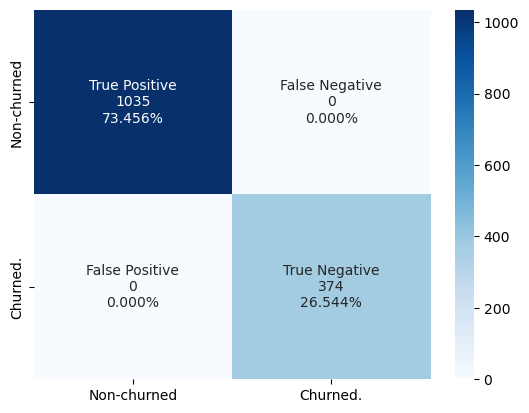

```python
# Predict class probabilities
y_pred_proba = model_FNN.predict(X_test_scaled)

# Predict class labels
y_pred_label = (y_pred_proba > 0.5)

metrics_score(y_test, y_pred_label, y_pred_proba)
```

```python
# Evaluate the model
test_loss, test_accuracy = model_FNN.evaluate(X_test_scaled, y_test, verbose=0)
print(f"Test Loss: {test_loss:}, Test Accuracy: {test_accuracy:.2f}")
```

```
Test Loss: 1.704762198073695e-08, Test Accuracy: 1.00
```

## **Interpretation of the results**

**The results of the FNN model applied to the prediction of churned customers using the Telco Customer Churn Dataset indicate an exceptionally high performance.**

### **2. Model Performance Metrics**

- **Recall (1.0000):** The model identifies **all churned customers** correctly, meaning it has no false negatives. This is critical for churn prediction since failing to detect churn could have significant business implications.
- **AUC-ROC Score (1.0000):** The model perfectly distinguishes between churned and non-churned customers, indicating no overlap in probability predictions for the two classes.
- **Accuracy, Precision, F1 Score (1.0000):** All these metrics being perfect suggests that the model is making no errors in classification.

### **3. Classification Report**

- Both churned (1) and non-churned (0) classes have **precision, recall, and F1 scores of 1.0000**, which is highly unusual in real-world datasets. This implies the model perfectly predicts the outcomes for all 1409 samples in the test set.

### **4. Confusion Matrix**

- **True Positives (1035):** All non-churned customers are correctly identified as non-churned.
- **True Negatives (374):** All churned customers are correctly identified as churned.
- **False Positives (0)** and **False Negatives (0)**: There are no misclassifications, which is rare and suggests either an overly simplified problem or data leakage.

### **6. Interpretations**

#### **Strengths:**

- **1.** The model demonstrates perfect performance on all metrics, which is ideal in theory.
- **2.** High recall and precision ensure that the model is both sensitive to churn detection and does not raise unnecessary false alarms.

#### **Concerns:**

- **1. Overfitting:**
  - The training accuracy and validation accuracy are both perfect or near-perfect across all epochs.
  - Loss values approach zero for both training and validation, which indicates the model memorized the data instead of generalizing patterns.
- **2. Data Leakage:**
  - The model might have access to information that directly or indirectly reveals the target variable (e.g., features that leak churn status).
  - Validation accuracy being perfect from the first epoch is unusual and strongly suggests leakage.
- **3. Simplified Problem:**
  - If the data lacks complexity or contains redundant, highly correlated features, the model may achieve perfect results without necessarily being robust for unseen data.

### **7. Overfitting Assessment**

Given that the test metrics are as high as the training and validation metrics, **there is no evidence of overfitting in this model** based on the provided results. However, the flawless performance warrants further investigation, as real-world datasets typically involve noise, randomness, and complexity that prevent perfect results.